# Group4_Phase_4_HCDR

Leveraging Machine Learning to Predict Loan Defaults

Home Credit Default Risk Group4 - Phase 4

Applied Machine Learning

December 10, 2024

- 1. Team and Project Management
- 2. Project Report
  - 2.1 Title
  - 2.2 Abstract
  - 2.3 Introduction
  - 2.4 Methods
  - 2.5 Results
  - 2.6 Discussion, Conclusion and Gap Analysis
  - 2.7 References
- 3. Code Appendix

## **1. Team and Project Management**

**Team Members**

| Name | Email | Role | Photo |
| --- | --- | --- | --- |
| Lexi Colwell | alecolwe@iu.edu | Phase 1 Lead |  |
| Nasheed Jafri | njafri@iu.edu | Phase 2 Lead |  |
| Cassie Cagwin | cacagwin@iu.edu | Phase 3 Lead |  |
| Maria Aroca | mparoca@iu.edu | Phase 4 Lead |  |

**Phase Task Description**

| Phase | Task Description | Project Manager |
| --- | --- | --- |
| Phase 1 | Project planning and proposal, including data sources, metrics, and baseline models | Lexi Colwell |
| Phase 2 | Data exploration (EDA), baseline pipeline, feature engineering, and initial hyperparameter tuning | Nasheed Jafri |
| Phase 3 | Advanced feature engineering, hyperparameter tuning, feature selection, and ensemble methods | Cassie Cagwin |
| Phase 4 | Final model integration, implementing advanced architectures, and project report completion | Maria Aroca |

Phase 4 Credit Assignment Plan Summary

| Name | Task Description | Estimated Time |
| --- | --- | --- |
| Lexi Colwell | Documented the modeling pipeline, including verifying data for potential leakage issues. | 15 hrs |
| Nasheed Jafri | Create exploratory data analysis (EDA) visualizations and organize insights for the final report. | 15 hrs |
| Cassie Cagwin | Develop models, create visuals for model performance,conduct experiments with MLP and kaggle submission and submission code | 15 hrs |
| Maria Aroca | Perform MLP model experiments and organize results for inclusion in the final submission. | 15 hrs |

## **2. Project Report**

## **2.1 Title**

**Leveraging Machine Learning to Predict Loan Defaults**

## **2.3 Introduction**

Many individuals face significant barriers to accessing loans due to insufficient or non-existent credit histories, often leaving them vulnerable to predatory lending practices. This project aims to address this issue by expanding financial inclusion for the unbanked population through the use of alternative data sources and the development of predictive models using machine learning techniques. Our primary objective was to predict loan repayment ability by employing a comprehensive modeling process to analyze credit default risk across an extensive historical collection of datasets.

This report has the following structure: In the **Methods** section, we briefly describe the data and detail how features were engineered and our modelling approach. Feature engineering played a crucial role in this process, transforming raw and heterogeneous data into meaningful features to create a final unified dataset as the base for our predictive models. We also describe the models we experimented with. This task was framed as a standard supervised classification problem, where the goal is to train models to predict loan repayment labels based on historical features.

The modeling process began with a baseline Logistic Regression model for its simplicity and interpretability and advanced to more complex models, including Decision Trees, Random Forests, Gradient Boosting, XGBoost, Light Gradient Boosting (LightGBM) and Support Vector Machines (SVM). To address the dataset's high dimensionality, we applied feature selection techniques such as correlation analysis, tree-based feature importance, and Principal Component Analysis (PCA), reducing the dataset to 20 relevant features. Ensemble methods, such as a voting classifier and a stacking classifier, were implemented to combine the predictions of multiple models. We also performed hyperparameter tuning on our best model. Additionally, we explored neural network-based approaches, implementing and evaluating Multi-Layer Perceptron (MLP) models with different architectures, including Sparse Input MLP, Simple Deep MLP, MLP with Dropout, and Wider MLP.

Finally, In the **Discussion** section, we address potential next steps to deal with the class imbalance problem, such as employing advanced resampling techniques or cost-sensitive methods. Our full code is presented in the **Code Appendix** at the end of the document.

## **2.4 Methods**

### **2.4.1 Data**

In our project we analyzed the data uploaded to the [Home Credit Default Risk kaggle](https://www.kaggle.com/competitions/home-credit-default-risk/data) competition project page. The data for this project represents a comprehensive and diverse collection of data sources related to credit applications and repayment behaviors, making it both rich in detail and complex to work with.

The dataset used in this study has a total size of **2.68 GB** and comprises various csv files, each containing distinct but complementary information related to loan applicants and their financial histories. Two primary files, *application_train.csv* and *application_test.csv*, provide detailed information about loans and loan applicants, serving as the foundation for training and testing the models.

The *POS_CASH_balance.csv* file contains monthly balance snapshots of previous point-of-sale (POS) transactions and cash loans associated with the applicants. The *bureau.csv* file captures data from previous loans reported to credit bureaus, while *bureau_balance.csv* offers monthly balance snapshots of credits tracked by these bureaus.

Additionally, the *credit_card_balance.csv* file includes monthly balance data for credit cards that applicants have with Home Credit. The *installments_payments.csv* file records historical payment data for loan installments, providing insight into payment behaviors. Finally, the *previous_application.csv* file contains application data for clients' previous loans with Home Credit. Together, these files provide a comprehensive view of applicant financial profiles and loan histories, enabling robust modeling and analysis.

*Table 1* shows the dimensions and size of each the files. For a detailed description of the columns of these csv files, please see the *data description* section of the Appendix.

**Table 1. Data Dimensions**

| Dataset | Dimensions (Rows x Columns) | Size |
| --- | --- | --- |
| application_train | 307,511 x 122 | 158 MB |
| application_test | 48,744 x 121 | 25 MB |
| bureau | 1,716,428 x 17 | 162 MB |
| bureau_balance | 27,299,925 x 3 | 358 MB |
| credit_card_balance | 3,840,312 x 23 | 405 MB |
| installments_payments | 13,605,401 x 8 | 690 MB |
| previous_application | 1,670,214 x 37 | 386 MB |
| POS_CASH_balance | 10,001,358 x 8 | 375 MB |

We accessed the dataset using the Kaggle API and created a function to unzip the downloaded files. The extracted data was then loaded and organized into a dictionary, allowing for efficient retrieval during the analysis. In *Figure 1*, we provide a code snippet illustrating this process.

> **Figure 1. Code Snippet of Data Download**

> ```
> 1  import os
> 2  import pandas as pd
> 3  import zipfile
> 4  import warnings
> 5
> 6  warnings.filterwarnings('ignore')
> 7
> 8  # Set Kaggle API credentials
> 9  os.environ['KAGGLE_USERNAME'] = "your username"
> 10  os.environ['KAGGLE_KEY'] = "your key"
> 11
> 12  # Download the dataset
> 13  !kaggle competitions download -c home-credit-default-risk -p /root/shared/I526_AML_Student/Assignments/Data/home-credit-default-risk
> 14
> 15  # Define the data directory path
> 16  DATA_DIR = "../../../Data/home-credit-default-risk"  # Ensure this points to the correct location
> 17
> 18  # Unzip the dataset
> 19  unzippingReq = True  # Set to True if unzipping is required
> 20  if unzippingReq:
> 21      zip_ref = zipfile.ZipFile(f'{DATA_DIR}/home-credit-default-risk.zip', 'r')
> 22      zip_ref.extractall(DATA_DIR)  # Extract all files to the data directory
> 23      zip_ref.close()
> 24
> 25  # Function to load data
> 26  def load_data(in_path, name):
> 27      df = pd.read_csv(in_path)
> 28      print(f"{name}: shape is {df.shape}")
> 29      print(df.info())
> 30      display(df.head(5))
> 31      return df
> 32
> 33  # Load the dataset into a dictionary
> 34  datasets = {}  # Store datasets in a dictionary for easier tracking
> 35  ds_name = 'application_train'
> 36  datasets[ds_name] = load_data(os.path.join(DATA_DIR, f'{ds_name}.csv'), ds_name)
> 37
> ```

We conducted **exploratory data analysis (EDA)** to gain an initial understanding of the datasets, identify missing values, and examining key trends and relationships. This process involved generating summary statistics, visualizing data distributions, and exploring correlations between variables to inform feature engineering decisions. Findings from this analysis, some of which will be described in the *Results* section, provided valuable insights into the structure of the data.

### **2.4.2 Data Lineage and Feature Engineering**

Managing the heterogeneity of the data was one of the primary challenges in this project. Each dataset captured unique aspects of a client’s financial behavior, often in different formats, requiring careful alignment to ensure consistency. The data included both static attributes (e.g., demographic details) and time-series data (e.g., monthly balances and installment payments), introducing a mix of snapshot and longitudinal records. Furthermore, inconsistent collection periods across datasets complicated synchronization, as data for the same client did not always span identical timeframes.

To address these challenges, the data pipeline was designed to systematically process and integrate information from multiple sources. A critical step in this pipeline was aggregating datasets to align with the unique loan application identifier (`SK_ID_CURR`). For example, datasets such as **installments_payments**, **credit_card_balance**, and **POS_CASH_balance** contained multiple entries per client, representing either monthly snapshots or individual transactions. These datasets were aggregated using statistical summaries to generate a single, consistent view for each loan application. This integration step ensured that all data sources were harmonized and usable for downstream predictive modeling. *Figure 2* illustrates the data lineage pipeline, which integrates multiple data sources into a coherent dataset for analysis.

**Figure 2. Data Lineage**

[figure not shown]

Feature engineering played a vital role in transforming raw data into meaningful predictors of client creditworthiness. Below, we describe the feature engineering process for each secondary dataset:

- **Previous Applications**: The *previous_application* dataset, containing historical loan applications, was processed using the **prevAppsFeaturesAggregater** function. Features were aggregated using statistical summaries (e.g., min, max, mean) on numeric attributes like `AMT_APPLICATION` and `AMT_ANNUITY`. A new feature, `range_AMT_APPLICATION`, representing the variability in loan request amounts, was created to capture fluctuations in financial needs, which are indicative of credit risk.
- **Credit Bureau**: The **BureauFeaturesAggregater** function processed the *bureau* dataset, which contained records of clients’ previous credits with other institutions. It included features such as `AMT_CREDIT_SUM` and `AMT_CREDIT_SUM_OVERDUE`. A new feature, `OVERDUE_CREDIT_RATIO`, was created to represent the ratio of overdue credit to the total credit. This ratio is a key indicator of financial risk, as a high value suggests difficulty in managing credit obligations.
- **Credit Card Balances**: The *credit_card_balance* dataset, containing monthly credit card records, was processed using the **CreditCardBalanceFeatureEngineer** and **CreditCardBalanceAggregator** functions. Features like `CREDIT_UTIL_RATIO` (ratio of balance to credit limit) and `DPD_MAX` (maximum days past due) were engineered to capture repayment behavior and credit utilization patterns.
- **Installment Payments**: The *installments_payments* dataset provided details on individual loan installment records. Using the **InstallmentsFeaturesAggregater** function, features such as `payment_delay_days` (difference between scheduled and actual payment dates) and `payment_to_installment_ratio` (proportion of payment made relative to the installment amount) were created. These features help capture repayment consistency over time.
- **POS and Cash Loans**: The *POS_CASH_balance* dataset, tracking POS and cash loans, was processed using the **POSCashBalanceFeaturesAggregater** function. New features, such as `POS_REMAINING_INSTALMENTS_RATIO` (ratio of remaining installments to total installments), were engineered to measure repayment progress.

To illustrate how we approached feature engineering, *Figure 3* provides a code example of one of our aggregators.

> **Figure 3. Code Snippet Feature Engineering on Installments Payments Example**

> ```
> 1  class InstallmentsFeaturesAggregater(BaseEstimator, TransformerMixin):
> 2      def __init__(self):
> 3          self.delay_agg_op = {
> 4              'payment_delay_days': ['mean', 'max']  # Include average_delay and max_delay
> 5          }
> 6          self.payment_agg_op = {
> 7              'amt_payment_difference': ['sum', 'std'],  # Include total_payment_difference and variability_payment_difference
> 8              'payment_to_installment_ratio': ['mean', 'max']  # Include average_payment_ratio and max_payment_ratio
> 9          }
> 10
> 11      def fit(self, X, y=None):
> 12          return self
> 13
> 14      def transform(self, X, y=None):
> 15
> 16          # Create new features
> 17          X['payment_delay_days'] = X['DAYS_ENTRY_PAYMENT'] - X['DAYS_INSTALMENT']
> 18          X['amt_payment_difference'] = X['AMT_INSTALMENT'] - X['AMT_PAYMENT']
> 19          X['payment_to_installment_ratio'] = X['AMT_PAYMENT'] / X['AMT_INSTALMENT']
> 20
> 21          # Aggregate delay features
> 22          delay_features = X.groupby('SK_ID_CURR').agg(self.delay_agg_op)
> 23          delay_features.columns = ['_'.join(col).strip() for col in delay_features.columns]
> 24
> 25          # Aggregate payment features
> 26          payment_features = X.groupby('SK_ID_CURR').agg(self.payment_agg_op)
> 27          payment_features.columns = ['_'.join(col).strip() for col in payment_features.columns]
> 28
> 29          # Combine both aggregated features
> 30          aggregated_features = pd.concat([delay_features, payment_features], axis=1)
> 31
> 32          return aggregated_features.reset_index()
> 33
> 34  # Test function for the updated InstallmentsFeaturesAggregater
> 35  def test_driver_InstallmentsFeaturesAggregater(df):
> 36      print(f"df.shape: {df.shape}\n")
> 37      print(f"Sample df columns: {df.columns}")
> 38      test_pipeline = make_pipeline(InstallmentsFeaturesAggregater())
> 39      result = test_pipeline.fit_transform(df)
> 40      return result
> ```

We used the aggregater functions we created to build a pipeline for each of these datasets. We merged the datasets sequentially into the primary application dataset using a left join on `SK_ID_CURR`. Each merge operation appended the aggregated features from the secondary dataset to the primary dataset. *Figure 4* shows a code example of this process.

> **Figure 4. Code Snippet of Final Dataset Creation**

> ```
> 1  import pandas as pd
> 2  from sklearn.pipeline import Pipeline
> 3  from sklearn.base import BaseEstimator, TransformerMixin
> 4
> 5  # Initialize pipelines for each dataset
> 6  bureau_feature_pipeline = Pipeline([
> 7      ('bureau_aggregater', BureauFeaturesAggregater(bureau_features))
> 8  ])
> 9
> 10  bureau_balance_feature_pipeline = Pipeline([
> 11      ('bureau_balance_aggregater', BureauBalanceFeaturesAggregater(features=bureau_balance_features))
> 12  ])
> 13
> 14  credit_card_feature_pipeline = Pipeline([
> 15      ('credit_card_aggregater', CreditCardFeaturesAggregater(features=ccb_features))
> 16  ])
> 17
> 18  installments_feature_pipeline = Pipeline([
> 19      ('installments_aggregater', InstallmentsFeaturesAggregater())
> 20  ])
> 21
> 22  pos_cash_feature_pipeline = Pipeline([
> 23      ('pos_cash_aggregater', POSCashBalanceFeaturesAggregater())
> 24  ])
> 25
> 26  prev_apps_feature_pipeline = Pipeline([
> 27      ('prev_apps_aggregater', prevAppsFeaturesAggregater(features))
> 28  ])
> 29
> 30  # Datasets
> 31  X_train = datasets['application_train']  # Primary dataset
> 32  bureau = datasets['bureau']
> 33  ID_combos = bureau[['SK_ID_CURR', 'SK_ID_BUREAU']].drop_duplicates()
> 34  bureau_balance = pd.merge(datasets['bureau_balance'], ID_combos, on='SK_ID_BUREAU', how='left')
> 35  credit_card_balance = datasets['credit_card_balance']
> 36  installments = datasets['installments_payments']
> 37  pos_cash = datasets['POS_CASH_balance']
> 38  previous_apps = datasets['previous_application']
> 39
> 40  merge_all_data = True
> 41
> 42  if merge_all_data:
> 43      # 1. Transform and merge Bureau/Bureau Balance data
> 44      bureau_aggregated = bureau_feature_pipeline.transform(bureau)
> 45      X_train = X_train.merge(bureau_aggregated, how='left', on='SK_ID_CURR')
> 46      bureau_balance_aggregated = bureau_balance_feature_pipeline.transform(bureau_balance)
> 47      X_train = X_train.merge(bureau_balance_aggregated, how='left', on='SK_ID_CURR')
> 48
> 49      # 2. Transform and merge Credit Card Balance data
> 50      credit_card_aggregated = credit_card_feature_pipeline.transform(credit_card_balance)
> 51      X_train = X_train.merge(credit_card_aggregated, how='left', on='SK_ID_CURR')
> 52
> 53      # 3. Transform and merge Installments data
> 54      installments_aggregated = installments_feature_pipeline.transform(installments)
> 55      X_train = X_train.merge(installments_aggregated, how='left', on='SK_ID_CURR')
> 56
> 57      # 4. Transform and merge POS Cash Balance data
> 58      pos_cash_aggregated = pos_cash_feature_pipeline.transform(pos_cash)
> 59      X_train = X_train.merge(pos_cash_aggregated, how='left', on='SK_ID_CURR')
> 60
> 61      # 5. Transform and merge Previous Applications data
> 62      previous_apps_aggregated = prev_apps_feature_pipeline.transform(previous_apps)
> 63      X_train = X_train.merge(previous_apps_aggregated, how='left', on='SK_ID_CURR')
> 64
> 65
> ```

### **2.4.3 Feature Selection**

To reduce dimensionality of the data, we initially tested **Principal Component Analysis (PCA)** alone, but we found none of the components individually explained a large proportion of the variance, meaning that many components (108) were still needed to explain a significant proportion of the variance, as shown in *Figure 5*.

**Figure 5. Initial PCA dimensionality reduction**

[figure not shown]

This led us to use another approach where we combined **correlation analysis**, **feature importance ranking**, and **Principal Component Analysis (PCA)** to select the most relevant features. With this new approach 20 PCA components explained 95% of the variance, which was an important improvement.

To do this, first, **correlation analysis** identified highly correlated feature pairs (correlation > 0.9), where only one feature from each pair (the one with the higher importance score) was retained to reduce multicollinearity. Next, **feature importance** was computed using **Decision Trees** and **Random Forests**, with scores averaged to prioritize impactful features.

Finally, **PCA** was applied to the reduced dataset, retaining components that explained 95% of the variance. This reduced the dataset to **20 features**, which, alongside the full set of features, were used in subsequent experiments. *Figure 6* illustrates this process.

> **Figure 6. Code Snippet of Feature Selection**

> ```
> 1  from sklearn.decomposition import PCA
> 2  # Correlation Analysis
> 3  def correlation_analysis(X, correlation_threshold=0.9):
> 4
> 5      #Identify pairs of highly correlated features and return the features to drop.
> 6      correlation_matrix = X.corr()
> 7
> 8      # Identify highly correlated pairs
> 9      correlated_features = set()
> 10      for i in range(len(correlation_matrix.columns)):
> 11          for j in range(i):
> 12              if abs(correlation_matrix.iloc[i, j]) > correlation_threshold:
> 13                  colname1 = correlation_matrix.columns[i]
> 14                  colname2 = correlation_matrix.columns[j]
> 15                  correlated_features.add((colname1, colname2))
> 16
> 17      print(f"Highly correlated feature pairs (|correlation| > {correlation_threshold}):")
> 18      for pair in correlated_features:
> 19          print(pair)
> 20
> 21      return correlated_features
> 22
> 23  # Feature Importance
> 24  def compute_feature_importance(X_train, y_train, preprocessor):
> 25
> 26      #Compute feature importance using Decision Tree and Random Forest models.
> 27
> 28      # Decision Tree
> 29      dt_model = Pipeline([
> 30          ('preprocessor', preprocessor),
> 31          ('decision_tree', DecisionTreeClassifier(random_state=42))
> 32      ])
> 33      dt_model.fit(X_train, y_train)
> 34      dt_importances = dt_model.named_steps['decision_tree'].feature_importances_
> 35
> 36      # Random Forest
> 37      rf_model = Pipeline([
> 38          ('preprocessor', preprocessor),
> 39          ('random_forest', RandomForestClassifier(random_state=42))
> 40      ])
> 41      rf_model.fit(X_train, y_train)
> 42      rf_importances = rf_model.named_steps['random_forest'].feature_importances_
> 43
> 44      # Extract feature names
> 45      preprocessed_features = preprocessor.get_feature_names_out().tolist()
> 46
> 47      # Ensure lengths match
> 48      if len(preprocessed_features) != len(dt_importances):
> 49          raise ValueError("Mismatch between preprocessed features and importance values.")
> 50
> 51      # Combine Results
> 52      importance_df = pd.DataFrame({
> 53          'Feature': preprocessed_features,
> 54          'DT_Importance': dt_importances,
> 55          'RF_Importance': rf_importances
> 56      })
> 57      importance_df['Average_Importance'] = importance_df[['DT_Importance', 'RF_Importance']].mean(axis=1)
> 58      importance_df.sort_values(by='Average_Importance', ascending=False, inplace=True)
> 59
> 60      return importance_df
> 61
> 62  # Combine Correlation and Feature Importance
> 63  def combine_correlation_and_importance(correlated_features, importance_df):
> 64
> 65      #For each correlated pair, retain the feature with higher average importance.
> 66
> 67      features_to_drop = set()
> 68      for col1, col2 in correlated_features:
> 69          avg_importance_col1 = importance_df.loc[importance_df['Feature'] == col1, 'Average_Importance'].values
> 70          avg_importance_col2 = importance_df.loc[importance_df['Feature'] == col2, 'Average_Importance'].values
> 71
> 72          if len(avg_importance_col1) > 0 and len(avg_importance_col2) > 0:
> 73              if avg_importance_col1[0] < avg_importance_col2[0]:
> 74                  features_to_drop.add(col1)
> 75              else:
> 76                  features_to_drop.add(col2)
> 77
> 78      return features_to_drop
> 79
> 80  # Feature Selection
> 81  def select_final_features(importance_df, features_to_drop, top_features_cutoff=20):
> 82
> 83      #Combine results of correlation analysis and feature importance to select features.
> 84
> 85      top_features = set(importance_df['Feature'].head(top_features_cutoff))
> 86      final_features = top_features - features_to_drop
> 87      return final_features
> 88
> 89  # Reapply PCA
> 90  def reapply_pca(X_train_reduced):
> 91
> 92     #Perform PCA on the reduced dataset.
> 93
> 94      from sklearn.decomposition import PCA
> 95      scaler = StandardScaler()
> 96      X_scaled = scaler.fit_transform(X_train_reduced)
> 97
> 98      pca = PCA(n_components=0.95, svd_solver='full', random_state=42)
> 99      X_pca = pca.fit_transform(X_scaled)
> 100
> 101      print(f"PCA explained variance ratio: {pca.explained_variance_ratio_}")
> 102      print(f"Number of components to retain 95% variance: {pca.n_components_}")
> 103      return X_pca, pca
> 104
> 105  # Correlation Analysis
> 106  correlated_features = correlation_analysis(X_train[numerical_features])
> 107
> 108  # Feature Importance
> 109  importance_df = compute_feature_importance(X_train, y_train, preprocessor)
> 110
> 111
> 112  # Combine Correlation and Importance
> 113  features_to_drop = combine_correlation_and_importance(correlated_features, importance_df)
> 114  print(f"Features to drop: {features_to_drop}")
> 115
> 116  # Select Final Features
> 117  final_features = select_final_features(importance_df, features_to_drop)
> 118  print(f"Final Selected Features: {final_features}")
> 119
> 120  # Get transformed feature names
> 121  transformed_feature_names = preprocessor.get_feature_names_out()
> 122
> 123  # Map selected features to transformed names
> 124  final_selected_features = [feature for feature in final_features if feature in transformed_feature_names]
> 125
> 126  # Debugging: Check for mismatches
> 127  missing_features = final_features - set(final_selected_features)
> 128  if missing_features:
> 129      print(f"Features not found in transformed feature names: {missing_features}")
> 130
> 131  # Filter Dataset
> 132  X_train_reduced = pd.DataFrame(preprocessor.transform(X_train), columns=transformed_feature_names)[final_selected_features]
> 133  X_test_reduced = pd.DataFrame(preprocessor.transform(X_test), columns=transformed_feature_names)[final_selected_features]
> 134  X_valid_reduced = pd.DataFrame(preprocessor.transform(X_valid), columns=transformed_feature_names)[final_selected_features]
> 135
> 136  # Verify the reduced dataset
> 137  print(f"Original Feature Count: {X_train.shape[1]}")
> 138  print(f"Reduced Feature Count: {X_train_reduced.shape[1]}")
> ```

### **2.4.4 Modeling Experiments**

Initial experiments included running Logistic Regression (our baseline model), Decision Trees, Random Forests, Gradient Boosting, XGBoost, and LightGBM on all 208 features. The same models were re-trained on the reduced dataset.

Due to efficiency constraints, we trained a Support Vector Machines (SVC) model with 20% of the training data on the reduced features.

We also experimented wtih voting and stacking ensemble models on both the complete and the reduced features.

These models were selected for their suitability for binary classification tasks and ability to handle large, diverse datasets with a mix of categorical and numerical features.

**Table 2. Model Implementation**

| Algorithm | Implementation | Loss Function |
| --- | --- | --- |
| Logistic Regression | `sklearn.linear_model.LogisticRegression` | Log Loss (Binary Cross-Entropy) |
| Decision Tree Classifier | `sklearn.tree.DecisionTreeClassifier` | Gini Impurity / Entropy |
| Random Forest | `sklearn.ensemble.RandomForestClassifier` | Gini Impurity / Entropy |
| Support Vector Machine | `sklearn.svm.SVC` | Hinge Loss (SVM Loss) |
| Gradient Boosting | `sklearn.ensemble.GradientBoostingClassifier` | Log Loss (Binary Cross-Entropy) |
| Extreme Gradient Boosting | `xgboost.XGBClassifier` | Log Loss (Binary Cross-Entropy) |
| Light Gradient Boosting | `lightgbm.LGBMClassifier` | Log Loss (Binary Cross-Entropy) |
| Voting Classifier | `sklearn.ensemble.VotingClassifier` | Weighted Average of Component Losses |
| Stacking Classifier | `sklearn.ensemble.StackingClassifier` | Meta-Model Loss |

- **Logistic Regression:** A straightforward and interpretable model for binary classification, used as a baseline to evaluate the performance of more advanced models.
- **Decision Tree Classifier:** Creates interpretable decision pathways by splitting on features. Helps understand which specific features indicate repayment likelihood.
- **Random Forest:** An ensemble of decision trees, offering robustness to overfitting and capturing complex, non-linear feature interactions.
- **Support Vector Machine (SVM):** Finds the optimal hyperplane for class separation, making it effective for high-dimensional feature spaces.
- **Gradient Boosting:** Sequentially builds models to correct the errors of prior models. Effective for structured data with complex, non-linear relationships.
- **Extreme Gradient Boosting (XGBoost):** An optimized version of gradient boosting with advanced features like regularization, missing value handling, and parallel processing for scalability.
- **Light Gradient Boosting (LightGBM):** Designed for speed and memory efficiency, handles large datasets and high-cardinality categorical features.
- **Voting Classifier:** Combines predictions from multiple models using a soft voting strategy, leveraging the strengths of each model for improved performance.
- **Stacking Classifier:** Uses a meta-model to combine the outputs of several base models, often leading to better generalization by exploiting model complementarities.

**Figure 7. Summary of Modeling Pipeline**

[figure not shown]

To evaluate our models for the HCDR dataset we used accuracy, precision, recall, F1 score, AUC-ROC, and log loss metrics, which are common metrics used to evaluate classification models. The results were logged in an experiments table. *Table 3* contains a description and formula for each metric.

**Table 3. Evaluation Metrics**

| Name | Description | Formula |
| --- | --- | --- |
| Accuracy | Proportion of correctly predicted samples out of the total samples | $$\text{Accuracy} = \frac{\text{True Positives + True Negatives}}{\text{True Positives + True Negatives + False Positives + False Negatives}}$$ |
| Precision | Proportion of true positive predictions out of all positive predictions | $$\text{Precision} = \frac{\text{True Positives}}{\text{True Positives} + \text{False Positives}}$$ |
| Recall (Sensitivity) | Proportion of actual positives correctly identified | $$\text{Recall} = \frac{\text{True Positives}}{\text{True Positives} + \text{False Negatives}}$$ |
| F1 Score | Harmonic mean of precision and recall, balancing the two metrics | $$\text{F1 Score} = 2 \cdot \frac{\text{Precision} \times \text{Recall}}{\text{Precision} + \text{Recall}}$$ |
| AUC-ROC | Area under the Receiver Operating Characteristic curve, measuring model's ability to distinguish between classes | $$\text{AUC-ROC} = \int \text{ROC Curve}$$ |
| Log Loss | Logarithmic loss penalizes wrong predictions more as they deviate from true class probabilities | $$\text{Log Loss} = -\frac{1}{m} \sum_{i=1}^{m} \sum_{k=1}^{K} y_k^{(i)} \log(\hat{p}_k^{(i)})$$ |

- **Accuracy** is the proportion of correctly predicted values divided by the total number of predicted values. It basically measures how often a machine learning model correctly predicts the outcome. This metric doesn't work well if the data set is imbalanced, meaning the overwhelming majority of the Target variables have the same classification.
- **Precision** is the proportion of true positive values predicted to the total number of positive values predicted. For projects where false positives are less desirable, precision is a good metric choice to minimize them.
- **Recall** is the proportion of true positive values predicted to the total number of the true positives and the total number of the false negatives. For projects where false negatives are less desirable, recall is a good metric choice.
- **F1 Score** is the harmonic mean of precision and recall. For projects where both false positives and false negatives are similarly weighted then F1 is a good metric choice.
- **AUC-ROC** is Area under the Receiver Operating Characteristic curve which measures a model's ability to distinguish between classes. AUC-ROC is a good metric choice for projects with highly imbalanced data sets.
- **Log (Logarithmic) loss** penalizes wrong predictions more as they deviate from true class probabilities. Log loss is a good metric choice for balanced and imbalanced data sets but can be sensitive to outliers.

*Figure 8* gives an example of the code used to train and evaluate our models on the full feature set, while *Figure 9* shows a code sample of our voting ensemble classifier. The full code of our experiments can be found in the Code Appendix.

> **Figure 8. Code Snippet of Modelling and Evaluation**

> ```
> 1  import pandas as pd
> 2  import numpy as np
> 3  from sklearn.model_selection import train_test_split, GridSearchCV
> 4  from sklearn.tree import DecisionTreeClassifier
> 5  from sklearn.ensemble import GradientBoostingClassifier, RandomForestClassifier
> 6  from sklearn.linear_model import LogisticRegression
> 7  from xgboost import XGBClassifier
> 8  from lightgbm import LGBMClassifier
> 9  from sklearn.pipeline import Pipeline
> 10  from sklearn.compose import ColumnTransformer
> 11  from sklearn.preprocessing import StandardScaler
> 12  from sklearn.impute import SimpleImputer
> 13  from category_encoders import TargetEncoder
> 14  from sklearn.metrics import classification_report, accuracy_score
> 15  from sklearn.metrics import roc_auc_score, precision_score, recall_score, f1_score, log_loss
> 16
> 17  # Define a dictionary of models
> 18  models = {
> 19      # "SVC": SVC(probability=True, random_state=42), # excluding due to high resource requirements
> 20      "LogisticRegression": LogisticRegression(random_state=42),
> 21      "DecisionTree": DecisionTreeClassifier(random_state=42),
> 22      "RandomForest": RandomForestClassifier(random_state=42),
> 23      "GradientBoosting": GradientBoostingClassifier(random_state=42),
> 24      "XGBoosting": XGBClassifier(random_state=42),
> 25      "LightGradientBoosting": LGBMClassifier(random_state=42)
> 26  }
> 27
> 28  # Split features into categorical and numerical groups
> 29  categorical_features = X_train.select_dtypes(include=['object', 'category']).columns.tolist()
> 30  numerical_features = X_train.select_dtypes(include=['int64', 'float64']).columns.tolist()
> 31
> 32  # Preprocessing pipelines for categorical and numerical data
> 33  categorical_transformer = Pipeline(steps=[
> 34      ('target_encoder', TargetEncoder(handle_unknown='ignore'))  # Encode categorical features
> 35  ])
> 36
> 37  numerical_transformer = Pipeline(steps=[
> 38      ('imputer', SimpleImputer(strategy='mean')),  # Impute missing values with mean
> 39      ('scaler', StandardScaler())  # Standardize numerical features
> 40  ])
> 41
> 42  # Combine preprocessing steps
> 43  preprocessor = ColumnTransformer(
> 44      transformers=[
> 45          ('num', numerical_transformer, numerical_features),
> 46          ('cat', categorical_transformer, categorical_features)
> 47      ]
> 48  )
> 49
> 50  # Create pipelines for each model
> 51  pipelines = {}
> 52  for model_name, model in models.items():
> 53      pipelines[model_name] = Pipeline(steps=[
> 54          ('preprocessor', preprocessor),
> 55          ('model', model)
> 56      ])
> 57
> 58  # Train each pipeline and store the trained models
> 59  %%time
> 60  best_models = {}
> 61  for model_name, pipeline in pipelines.items():
> 62      print(f"Training {model_name}...")
> 63      pipeline.fit(X_train, y_train)
> 64      best_models[model_name] = pipeline
> 65
> 66  # Initialize experiment log DataFrame
> 67  try:
> 68      expLog
> 69  except NameError:
> 70      expLog = pd.DataFrame(columns=[
> 71          'Experiment_Name', 'Train_Accuracy', 'Valid_Accuracy', 'Test_Accuracy',
> 72          'Train_ROC_AUC', 'Valid_ROC_AUC', 'Test_ROC_AUC',
> 73          'Train_Precision', 'Valid_Precision', 'Test_Precision',
> 74          'Train_Recall', 'Valid_Recall', 'Test_Recall',
> 75          'Train_F1', 'Valid_F1', 'Test_F1',
> 76          'Train_Log_Loss', 'Valid_Log_Loss', 'Test_Log_Loss'
> 77      ])
> 78
> 79  # Function to log model performance metrics
> 80  def populate_expLog(X_train, X_valid, X_test, model_name, model):
> 81      exp_name = f"{model_name}_{X_train.shape[1]}_features"
> 82      global expLog
> 83      expLog.loc[len(expLog)] = [f"{exp_name}"] + list(np.round(
> 84          [
> 85              accuracy_score(y_train, model.predict(X_train)),
> 86              accuracy_score(y_valid, model.predict(X_valid)),
> 87              accuracy_score(y_test, model.predict(X_test)),
> 88              roc_auc_score(y_train, model.predict_proba(X_train)[:, 1]),
> 89              roc_auc_score(y_valid, model.predict_proba(X_valid)[:, 1]),
> 90              roc_auc_score(y_test, model.predict_proba(X_test)[:, 1]),
> 91              precision_score(y_train, model.predict(X_train)),
> 92              precision_score(y_valid, model.predict(X_valid)),
> 93              precision_score(y_test, model.predict(X_test)),
> 94              recall_score(y_train, model.predict(X_train)),
> 95              recall_score(y_valid, model.predict(X_valid)),
> 96              recall_score(y_test, model.predict(X_test)),
> 97              f1_score(y_train, model.predict(X_train)),
> 98              f1_score(y_valid, model.predict(X_valid)),
> 99              f1_score(y_test, model.predict(X_test)),
> 100              log_loss(y_train, model.predict_proba(X_train)[:, 1]),
> 101              log_loss(y_valid, model.predict_proba(X_valid)[:, 1]),
> 102              log_loss(y_test, model.predict_proba(X_test)[:, 1])
> 103          ],
> 104          4
> 105      ))
> 106
> 107  # Evaluate each model and log results
> 108  for model_name, model in best_models.items():
> 109      y_pred = model.predict(X_test)
> 110      print(f"\n{model_name} Performance:")
> 111      print(f"Accuracy: {accuracy_score(y_test, y_pred):.4f}")
> 112      print(classification_report(y_test, y_pred))
> 113      populate_expLog(X_train, X_valid, X_test, model_name, model)
> 114
> ```

> **Figure 9. Code Snippet of Voting Ensemble Model**

> ```
> 1  import pandas as pd
> 2  import numpy as np
> 3  from sklearn.pipeline import Pipeline
> 4  from sklearn.compose import ColumnTransformer
> 5  from sklearn.preprocessing import StandardScaler
> 6  from sklearn.impute import SimpleImputer
> 7  from category_encoders import TargetEncoder
> 8  from sklearn.linear_model import LogisticRegression
> 9  from sklearn.tree import DecisionTreeClassifier
> 10  from sklearn.ensemble import RandomForestClassifier, GradientBoostingClassifier, VotingClassifier
> 11  from xgboost import XGBClassifier
> 12  from lightgbm import LGBMClassifier
> 13  from sklearn.metrics import classification_report, accuracy_score
> 14
> 15  # Define the best models for the voting classifier
> 16  best_models = {
> 17      # "SVC": SVC(probability=True, random_state=42), # Excluded due to resource constraints
> 18      "LogisticRegression": LogisticRegression(random_state=42),
> 19      "DecisionTree": DecisionTreeClassifier(random_state=42),
> 20      "RandomForest": RandomForestClassifier(random_state=42),
> 21      "GradientBoosting": GradientBoostingClassifier(random_state=42),
> 22      "XGBoosting": XGBClassifier(random_state=42),
> 23      "LightGradientBoosting": LGBMClassifier(random_state=42)
> 24  }
> 25
> 26  # Define feature types for preprocessing
> 27  categorical_features = X_train.select_dtypes(include=['object', 'category']).columns.tolist()
> 28  numerical_features = X_train.select_dtypes(include=['int64', 'float64']).columns.tolist()
> 29
> 30  # Create preprocessing pipelines for categorical and numerical data
> 31  categorical_transformer = Pipeline(steps=[
> 32      ('target_encoder', TargetEncoder(handle_unknown='ignore'))  # Encode categorical features
> 33  ])
> 34
> 35  numerical_transformer = Pipeline(steps=[
> 36      ('imputer', SimpleImputer(strategy='mean')),  # Impute missing values with mean
> 37      ('scaler', StandardScaler())  # Standardize numerical features
> 38  ])
> 39
> 40  # Combine the preprocessing pipelines into a single preprocessor
> 41  voting_preprocessor = ColumnTransformer(
> 42      transformers=[
> 43          ('num', numerical_transformer, numerical_features),
> 44          ('cat', categorical_transformer, categorical_features)
> 45      ]
> 46  )
> 47
> 48  # Create pipelines for each model with preprocessing
> 49  voting_pipelines = {}
> 50  for model_name, model in best_models.items():
> 51      voting_pipelines[model_name] = Pipeline(steps=[
> 52          ('preprocessor', voting_preprocessor),
> 53          ('model', model)
> 54      ])
> 55
> 56  # Combine the models into a voting classifier
> 57  voting_estimators = [
> 58      (name, Pipeline([
> 59          ('preprocessor', voting_preprocessor),
> 60          ('model', model)
> 61      ]))
> 62      for name, model in best_models.items()
> 63  ]
> 64  voting_clf = VotingClassifier(estimators=voting_estimators, voting='soft')
> 65
> 66  # Train the voting classifier
> 67  %%time
> 68  voting_clf.fit(X_train, y_train)
> 69
> 70  # Evaluate the voting classifier on the test set
> 71  y_pred_voting = voting_clf.predict(X_test)
> 72  print("\nVoting Classifier Performance:")
> 73  print(f"Accuracy: {accuracy_score(y_test, y_pred_voting):.4f}")
> 74  print(classification_report(y_test, y_pred_voting))
> 75
> 76  # Log performance metrics
> 77  populate_expLog(X_train, X_valid, X_test, "Voting_ensemble", voting_clf)
> 78
> ```

We selected specific hyperparameters to test the performance and optimized the XGBoost model based on its functionality and typical impact on classification tasks:

- **`learning_rate`**: This parameter controls the step size at each iteration while updating weights, impacting how quickly the model learns. We chose values `[0.1, 0.2]` to test a moderate learning rate range, balancing convergence speed and potential overfitting.
- **`max_depth`**: This determines the maximum depth of the trees, controlling the model's capacity to capture complex interactions. Values `[3, 5, 7]` were selected to explore shallow to moderately deep trees, balancing interpretability and overfitting risk.
- **`subsample`**: This specifies the fraction of training data used to grow trees, helping to reduce overfitting. We tested `[0.8, 1.0]` to compare the impact of using all data versus a slightly reduced sample.
- **`colsample_bytree`**: This parameter defines the fraction of features randomly sampled for each tree. Values `[0.8, 1.0]` were chosen to assess how limiting features per tree affects model performance and generalization.

*Figure 10* shows a code snippet from our hyperparamter tuning on XGBoost.

> **Figure 10. Code Snippet of Hyperparamteter tuning**

> ```
> 1  import pandas as pd
> 2  import numpy as np
> 3  from sklearn.pipeline import Pipeline
> 4  from sklearn.compose import ColumnTransformer
> 5  from sklearn.preprocessing import StandardScaler
> 6  from sklearn.impute import SimpleImputer
> 7  from category_encoders import TargetEncoder
> 8  from sklearn.model_selection import GridSearchCV
> 9  from xgboost import XGBClassifier
> 10
> 11  # Define the model and hyperparameter grid for tuning
> 12  models_PCA_tuning = {
> 13      "XGBoost": {
> 14          "model": XGBClassifier(use_label_encoder=False, eval_metric='logloss', random_state=42),
> 15          "params": {
> 16              "learning_rate": [0.1, 0.2],  # Learning rate values to test
> 17              # "n_estimators": [100, 200, 500],  # Uncomment if testing more estimators
> 18              "max_depth": [3, 5, 7],  # Depth of the trees
> 19              "subsample": [0.8, 1.0],  # Subsampling ratio of the training instances
> 20              "colsample_bytree": [0.8, 1.0]  # Subsampling ratio of columns by tree
> 21          }
> 22      }
> 23  }
> 24
> 25  # Identify categorical and numerical features
> 26  categorical_features = X_train_reduced.select_dtypes(include=['object', 'category']).columns.tolist()
> 27  numerical_features = X_train_reduced.select_dtypes(include=['int64', 'float64']).columns.tolist()
> 28
> 29  # Preprocessing pipelines for categorical and numerical data
> 30  categorical_transformer = Pipeline(steps=[
> 31      ('target_encoder', TargetEncoder(handle_unknown='ignore'))  # Encode categorical variables
> 32  ])
> 33
> 34  numerical_transformer = Pipeline(steps=[
> 35      ('imputer', SimpleImputer(strategy='mean')),  # Fill missing values with mean
> 36      ('scaler', StandardScaler())  # Standardize numerical features
> 37  ])
> 38
> 39  # Combine the preprocessing steps
> 40  preprocessor = ColumnTransformer(
> 41      transformers=[
> 42          ('num', numerical_transformer, numerical_features),
> 43          ('cat', categorical_transformer, categorical_features)
> 44      ]
> 45  )
> 46
> 47  # Create pipelines for models and tune using GridSearchCV
> 48  pipelines = []
> 49  for model_name, model_info in models_PCA_tuning.items():
> 50      pipeline = Pipeline(steps=[
> 51          ('preprocessor', preprocessor),  # Apply preprocessing
> 52          ('model', model_info['model'])  # Add model
> 53      ])
> 54
> 55      # Prepare the parameter grid for the model
> 56      param_grid = {f"model__{param_name}": param_values for param_name, param_values in model_info['params'].items()}
> 57
> 58      # Perform GridSearchCV to find the best parameters
> 59      grid_search = GridSearchCV(
> 60          estimator=pipeline,
> 61          param_grid=param_grid,
> 62          cv=3,  # 3-fold cross-validation
> 63          scoring='accuracy',  # Optimize for accuracy
> 64          n_jobs=-1  # Use all available cores
> 65      )
> 66
> 67      pipelines.append((model_name, grid_search))
> 68
> 69  # Train models and store the best estimators
> 70  best_models_PCA_tuning = {}
> 71  for model_name, grid_search in pipelines:
> 72      print(f"Training {model_name}...")
> 73      grid_search.fit(X_train_reduced, y_train)
> 74      best_models_PCA_tuning[model_name] = grid_search.best_estimator_  # Store the best model
> 75
> 76  # Extract best parameters for each model
> 77  best_params = []
> 78  for model_name, grid_search in pipelines:
> 79      best_params.append({
> 80          'Model': model_name,
> 81          **grid_search.best_params_  # Add best parameters to the dictionary
> 82      })
> 83
> 84  # Convert best parameters to a DataFrame for visualization
> 85  best_params_df = pd.DataFrame(best_params)
> 86
> 87  # Print the best parameters in a formatted output
> 88  print("Best Parameters for Each Model:\n")
> 89  for index, row in best_params_df.iterrows():
> 90      print(f"Model: {row['Model']}")
> 91      for param, value in row.items():
> 92          if param != 'Model':
> 93              print(f"  {param}: {value}")
> 94      print("-" * 40)  # Separator for readability
> ```

### **2.4.5 MLP Implementation**

For our Multi-Layer Perceptron (MLP) experiments, we explored multiple architectures to benchmark performance and evaluate different strategies for improving model efficacy. These included a **Sparse Input MLP** for baseline comparisons, a **Simple Deep MLP** with additional depth, an **MLP with Dropout** to mitigate overfitting, and a **Wider MLP** designed to enhance representational capacity.

We implemented an MLP using **PyTorch Lightning**. The baseline architecture consisted of two hidden layers with 64 and 32 units, respectively, each followed by ReLU activation. The output layer was configured for binary classification. Preprocessing was handled through a pipeline, where numerical features were standardized, and categorical variables were encoded before training.

Models were trained for 20 epochs with a batch size of 64, utilizing GPU acceleration to improve computational efficiency. After training, the best checkpoint was reloaded and evaluated on the test set to measure final performance. **TensorBoard** was employed to track training metrics and visualize the learning process.

To test different architectures, we ran the following experiments using the `run_experiment` function:

- **Sparse Input MLP:** Two hidden layers with `(64, 32)` units.
- **Simple Deep MLP:** Three hidden layers with `(128, 64, 32)` units.
- **MLP with Dropout:** Three hidden layers with `(128, 64, 32)` units and a dropout rate of 0.2.
- **Wider MLP:** Three hidden layers with `(512, 256, 128)` units.

Results from each experiment were logged to ensure consistent evaluation and comparison across architectures. These experiments provided valuable insights into the impact of architectural variations on model performance.

**Figure 11. MLP Pipeline**

[figure not shown]

> ```
> 1  # Install necessary dependencies
> 2  !pip install pytorch-lightning torch torchvision torchmetrics
> 3
> 4  # Import required libraries
> 5  import pytorch_lightning as pl
> 6  import torch
> 7  import torch.nn as nn
> 8  from torchmetrics import Accuracy
> 9  from torchmetrics.functional import precision, recall, f1_score, auroc
> 10  from pkg_resources import parse_version
> 11  from torchmetrics import __version__ as torchmetrics_version
> 12  from torch.utils.data import DataLoader, TensorDataset, random_split
> 13  import pandas as pd
> 14  from sklearn.preprocessing import StandardScaler
> 15
> 16  class MultiLayerPerceptron(pl.LightningModule):
> 17      def __init__(self, input_dim, hidden_units=(64, 32)):
> 18          super().__init__()
> 19
> 20          # Define accuracy metrics based on PyTorch Lightning version
> 21          if parse_version(torchmetrics_version) > parse_version("0.8"):
> 22              self.train_acc = Accuracy(task="multiclass", num_classes=2)  # Adjust num_classes
> 23              self.valid_acc = Accuracy(task="multiclass", num_classes=2)
> 24              self.test_acc = Accuracy(task="multiclass", num_classes=2)
> 25          else:
> 26              self.train_acc = Accuracy()
> 27              self.valid_acc = Accuracy()
> 28              self.test_acc = Accuracy()
> 29
> 30          # Define MLP architecture
> 31          all_layers = [nn.Flatten()]
> 32          for hidden_unit in hidden_units:
> 33              all_layers.append(nn.Linear(input_dim, hidden_unit))
> 34              all_layers.append(nn.ReLU())
> 35              input_dim = hidden_unit
> 36          all_layers.append(nn.Linear(hidden_units[-1], 2))  # Output layer for binary classification
> 37          self.model = nn.Sequential(*all_layers)
> 38
> 39      def forward(self, x):
> 40          return self.model(x)
> 41
> 42      def training_step(self, batch, batch_idx):
> 43          x, y = batch
> 44          logits = self(x)
> 45          loss = nn.functional.cross_entropy(logits, y)
> 46          preds = torch.argmax(logits, dim=1)
> 47          self.train_acc.update(preds, y)
> 48          self.log("train_loss", loss, prog_bar=True)
> 49          self.log("train_acc", self.train_acc.compute(), prog_bar=True)  # Log train accuracy
> 50
> 51          train_precision = precision(preds, y, task="binary")
> 52          train_recall = recall(preds, y, task="binary")
> 53          train_f1 = f1_score(preds, y, task="binary")
> 54          train_roc_auc = auroc(logits.softmax(dim=-1)[:, 1], y, task="binary")
> 55          self.log("train_precision", train_precision, prog_bar=True)
> 56          self.log("train_recall", train_recall, prog_bar=True)
> 57          self.log("train_f1", train_f1, prog_bar=True)
> 58          self.log("train_roc_auc", train_roc_auc, prog_bar=True)
> 59
> 60          return loss
> 61
> 62      def validation_step(self, batch, batch_idx):
> 63          x, y = batch
> 64          logits = self(x)
> 65          loss = nn.functional.cross_entropy(logits, y)
> 66          preds = torch.argmax(logits, dim=1)
> 67          self.valid_acc.update(preds, y)
> 68          self.log("valid_loss", loss, prog_bar=True)
> 69          self.log("valid_acc", self.valid_acc.compute(), prog_bar=True)  # Log validation accuracy
> 70
> 71          valid_precision = precision(preds, y, task="binary")
> 72          valid_recall = recall(preds, y, task="binary")
> 73          valid_f1 = f1_score(preds, y, task="binary")
> 74          valid_roc_auc = auroc(logits.softmax(dim=-1)[:, 1], y, task="binary")
> 75          self.log("valid_precision", valid_precision, prog_bar=True)
> 76          self.log("valid_recall", valid_recall, prog_bar=True)
> 77          self.log("valid_f1", valid_f1, prog_bar=True)
> 78          self.log("valid_roc_auc", valid_roc_auc, prog_bar=True)
> 79
> 80          return loss
> 81
> 82      def test_step(self, batch, batch_idx):
> 83          x, y = batch
> 84          logits = self(x)
> 85          loss = nn.functional.cross_entropy(logits, y)
> 86          preds = torch.argmax(logits, dim=1)
> 87          self.test_acc.update(preds, y)
> 88          self.log("test_loss", loss, prog_bar=True)
> 89          self.log("test_acc", self.test_acc.compute(), prog_bar=True)  # Log test accuracy
> 90
> 91          test_precision = precision(preds, y, task="binary")
> 92          test_recall = recall(preds, y, task="binary")
> 93          test_f1 = f1_score(preds, y, task="binary")
> 94          test_roc_auc = auroc(logits.softmax(dim=-1)[:, 1], y, task="binary")
> 95          self.log("test_precision", test_precision, prog_bar=True)
> 96          self.log("test_recall", test_recall, prog_bar=True)
> 97          self.log("test_f1", test_f1, prog_bar=True)
> 98          self.log("test_roc_auc", test_roc_auc, prog_bar=True)
> 99
> 100
> 101          return loss
> 102
> 103      def configure_optimizers(self):
> 104          return torch.optim.Adam(self.parameters(), lr=0.001)
> 105
> 106  # Data preprocessing
> 107  scaler = StandardScaler()
> 108  X_train_reduced = pd.DataFrame(scaler.fit_transform(X_train_reduced), columns=X_train_reduced.columns)
> 109  X_test_reduced = pd.DataFrame(scaler.transform(X_test_reduced), columns=X_test_reduced.columns)
> 110
> 111  # Convert data to PyTorch tensors
> 112  X_train_tensor = torch.tensor(X_train_reduced.values, dtype=torch.float32)
> 113  y_train_tensor = torch.tensor(y_train.values, dtype=torch.long)
> 114  X_test_tensor = torch.tensor(X_test_reduced.values, dtype=torch.float32)
> 115  y_test_tensor = torch.tensor(y_test.values, dtype=torch.long)
> 116
> 117  # Create datasets and dataloaders
> 118  batch_size = 64
> 119  dataset = TensorDataset(X_train_tensor, y_train_tensor)
> 120  train_size = int(0.8 * len(dataset))
> 121  val_size = len(dataset) - train_size
> 122  train_dataset, val_dataset = random_split(dataset, [train_size, val_size])
> 123  test_dataset = TensorDataset(X_test_tensor, y_test_tensor)
> 124
> 125  train_loader = DataLoader(train_dataset, batch_size=batch_size, shuffle=True)
> 126  val_loader = DataLoader(val_dataset, batch_size=batch_size)
> 127  test_loader = DataLoader(test_dataset, batch_size=batch_size)
> 128
> 129  # Define a custom PyTorch Lightning DataModule
> 130  class CustomDataModule(pl.LightningDataModule):
> 131      def __init__(self, X_train, X_test, y_train, y_test, batch_size=64):
> 132          super().__init__()
> 133          self.X_train = X_train
> 134          self.X_test = X_test
> 135          self.y_train = y_train
> 136          self.y_test = y_test
> 137          self.batch_size = batch_size
> 138          self.input_dim = X_train.shape[1]
> 139
> 140      def setup(self, stage=None):
> 141          dataset = TensorDataset(torch.tensor(self.X_train.values, dtype=torch.float32),
> 142                                   torch.tensor(self.y_train.values, dtype=torch.long))
> 143          train_size = int(0.8 * len(dataset))
> 144          val_size = len(dataset) - train_size
> 145          self.train_dataset, self.val_dataset = random_split(dataset, [train_size, val_size])
> 146          self.test_dataset = TensorDataset(torch.tensor(self.X_test.values, dtype=torch.float32),
> 147                                            torch.tensor(self.y_test.values, dtype=torch.long))
> 148
> 149      def train_dataloader(self):
> 150          return DataLoader(self.train_dataset, batch_size=self.batch_size, shuffle=True)
> 151
> 152      def val_dataloader(self):
> 153          return DataLoader(self.val_dataset, batch_size=self.batch_size)
> 154
> 155      def test_dataloader(self):
> 156          return DataLoader(self.test_dataset, batch_size=self.batch_size)
> 157
> 158  # Initialize the DataModule
> 159  data_module = CustomDataModule(X_train_reduced, X_test_reduced, y_train, y_test, batch_size=batch_size)
> 160
> 161  # Define and run experiments
> 162  experiment_logs = []
> 163  def run_experiment(model_name, hidden_units, dropout_rate=None):
> 164      if dropout_rate:
> 165          class DropoutMLP(MultiLayerPerceptron):
> 166              def __init__(self, input_dim, hidden_units, dropout_rate):
> 167                  super().__init__(input_dim, hidden_units)
> 168                  layers = []
> 169                  for hidden_unit in hidden_units:
> 170                      layers.append(nn.Linear(input_dim, hidden_unit))
> 171                      layers.append(nn.ReLU())
> 172                      layers.append(nn.Dropout(p=dropout_rate))
> 173                      input_dim = hidden_unit
> 174                  layers.append(nn.Linear(hidden_units[-1], 2))
> 175                  self.model = nn.Sequential(*layers)
> 176          model = DropoutMLP(input_dim=data_module.input_dim, hidden_units=hidden_units, dropout_rate=dropout_rate)
> 177      else:
> 178          model = MultiLayerPerceptron(input_dim=data_module.input_dim, hidden_units=hidden_units)
> 179
> 180      trainer = pl.Trainer(
> 181          max_epochs=20,
> 182          accelerator="gpu" if torch.cuda.is_available() else "cpu",
> 183          devices=1 if torch.cuda.is_available() else None,
> 184      )
> 185      trainer.fit(model, datamodule=data_module)
> 186      results = trainer.test(model=model, dataloaders=data_module.test_dataloader(), verbose=False)
> 187
> 188      metrics = {
> 189          "Experiment_Name": model_name,
> 190          "Hidden_Units": hidden_units,
> 191          "Dropout_Rate": dropout_rate,
> 192          "Test_Accuracy": results[0]["test_acc"],
> 193          "Test_Loss": results[0]["test_loss"],
> 194          "Test_Precision": results[0]["test_precision"],
> 195          "Test_Recall": results[0]["test_recall"],
> 196          "Test_ROC_AUC": results[0]["test_roc_auc"],
> 197          "Test_F1": results[0]["test_f1"],
> 198      }
> 199      experiment_logs.append(metrics)
> 200      print(f"Experiment {model_name} complete!")
> 201
> 202  # Run experiments
> 203  run_experiment("Sparse Input MLP", hidden_units=(64, 32))
> 204  run_experiment("Simple Deep MLP", hidden_units=(128, 64, 32))
> 205  run_experiment("MLP with Dropout", hidden_units=(128, 64, 32), dropout_rate=0.2)
> 206  run_experiment("Wider MLP", hidden_units=(512, 256, 128))
> 207
> 208  # Start TensorBoard
> 209  %load_ext tensorboard
> 210  %tensorboard --logdir lightning_logs/
> 211
> ```

**Figure 12. Tensorboard use**

[figure not shown]

### **2.4.6 Data Leakage Mitigation**

**Data Leakage**

Data leakage refers to using information during model training that is outside of the training dataset (e.g., test data, future data, features derived from the target variable). This error often occurs when training and test data are not split at the correct time in the pipeline, so the test data is shared with training data. Data leakage is an issue because it causes the model to appear better performing than it actually will be in a real-world application. The model is likely to overfit because it is using all of the data to train instead of just the training set. Thus, the test metrics will likely be high, but these scores are not a good reflection of how the model will perform on unseen data.

Data leakage is a common error in machine learning because it usually occurs subtly. Machine learning pipelines are often complex with many different steps where data is processed or analyzed, so it can be difficult to detect leakage. Below, we discuss what can be done to detect and fix data leakage, as well as what we did to minimize data leakage in our project.

**Ways to detect and fix leakage:** One way to identify data leakage is to compare the training and test metrics. If there are large differences where the training metrics are much better than the test metrics, it is an indication that data leakage may be occurring somewhere in your pipeline. Another sign of possible data leakage is a strong unexpected or illogical correlation between a feature and the target variable. This strong association can occur if information from the target variable was used to create other features. Finally, if the model shows inconsistent performance across different datasets, there may be a data leakage issue. The model will likely perform well on unseen data similar to the test set, but more varied datasets will result in poor model performance.

If you suspect leakage in your pipeline, you should first ensure that train/test split is performed before any preprocessing of the data. Feature engineering steps should also be checked to make sure that future data (data that would not be available at time of training/prediction) and target variable information (e.g., feature derived from the target variable) are not included in your model training. You can then remove any features that are found to have illogically high feature importance or strong illogical correlations with the target variable.

**What we did to minimize leakage:** An important step in minimizing data leakage is to ensure the train/test split is performed before preprocessing is done on the data. Preprocessing includes operations such as scaling, imputing missing values, and encoding categorical variables. In our pipeline, we performed the train/test split after merging the secondary tables with the primary data table (Application Train). The splitting of the training and testing data occurs before preprocessing done with the Categorical and Numerical Transformers. Splitting the data before preprocessing is important because none of the values from test data should be used to scale/impute/encode the values in the training data. The preprocessing is performed separately on the training and test sets so no information is shared between the two sets.

In the next section, we will present our main findings of our experiments.

## **2.5 Results**

### **2.5.1 Exploratory Data Analysis Key Insights**

The data reveals a significant class imbalance in the target variable, with 92% of applicants successfully repaying their loans and only 8% encountering payment difficulties (Figure 13).

**Figure 13. Distribution of the Target Variable**

[figure not shown]

An analysis of applicant occupations (*Figure 14*) shows that most clients were laborers, while the fewest were IT and HR professionals. This distribution reflects the nature of loan applicants, where low credit history applications are typically more prevalent among labor-intensive professions.

**Figure 14. Loan Application Occupation**

[figure not shown]

Default rates varied significantly across income, education, family, and housing types (*Figure 15*). Individuals on maternity leave or unemployed exhibited the highest default rates, suggesting increased financial vulnerability in these groups. Conversely, those with academic degrees had the lowest default rates, highlighting the stabilizing effect of higher education on financial behavior. These findings suggest that income stability, education level, and family status are key factors influencing repayment outcomes.

**Figure 15. Default Percentages by Income, Education, Family Status and Housing Type**

[figure not shown]

*Figure 16* illustrates the distribution of credit card balance records relative to the months before the loan application. The data shows an increasing number of entries as the timeline approaches the loan application date, with the highest number of records occurring in the final months prior to the application. This trend suggests that credit card activity is most actively recorded closer to the application, possibly reflecting a focus on recent financial behavior in creditworthiness assessments.

**Figure 16.Credit Card Balances Months Relative to Application**

[figure not shown]

*Figure 17* shows the distribution of credit card history categorized into three groups: long-term histories (greater than 7 years), medium-term histories (3 to 7 years), and short-term histories (less than 3 years). The majority of clients have long credit card histories, accounting for the largest share of the data. Medium-term and short-term histories are represented in nearly equal proportions but are significantly fewer than long-term histories. This distribution indicates that most clients possess well-established credit histories, which may serve as a strong indicator for creditworthiness evaluations.

**Figure 17.Distribution of Credit Card History**

[figure not shown]

*Figure 18* presents the histograms of DAYS_INSTALLMENT and DAYS_ENTRY_PAYMENT, representing the days relative to the loan application date when installments were scheduled and payments were made, respectively. Both distributions show that the frequency of entries increases as the timeline approaches zero, with a sharp peak close to the application date. This indicates that most installment-related activities occur shortly before or near the loan application.

Similarly, *Figure 19* shows a steady increase in entries as the timeline approaches the loan application date. CNT_INSTALMENT_FUTURE (remaining installments) highlights a sharp decline as the number of future payments decreases.

**Figure 18. Distribution of Days Installment and Days Entry Payment**

[figure not shown]

**Figure 19. Distributions of POS_CASH_balance**

[figure not shown]

The exploratory data analysis provided critical insights into the structure and characteristics of the data, guiding the necessary feature engineering and preprocessing steps.These insights directly informed the development of the modeling pipeline, enabling the transformation of raw data into inputs suitable for predictive analysis. Next we will present the results of the models.

### **2.5.2 Modeling Results**

Our modeling experiments evaluated nine algorithms: Logistic Regression, Decision Trees, Random Forests, Gradient Boosting, XGBoost, and Light Gradient Boosting (LightGBM), SVM with 20% of training data and Voting and Stacking Ensemble Models. Each model was tested on both the full feature set (208 features) and a reduced feature set (20 features), except for SVM that was only tested on the reduced feature set. The evaluation metrics are presented in *Table 4* and *Figure 20* compares the key evaluation metrics across models. MLP results will be presented in the following subsection.

**Table 4. Metrics Across Experiments without MLP**

|  | **Experiment_Name** | **Train_Accuracy** | **Valid_Accuracy** | **Test_Accuracy** | **Train_ROC_AUC** | **Valid_ROC_AUC** | **Test_ROC_AUC** | **Train_Precision** | **Valid_Precision** | **Test_Precision** | **Train_Recall** | **Valid_Recall** | **Test_Recall** | **Train_F1** | **Valid_F1** | **Test_F1** | **Train_Log_Loss** | **Valid_Log_Loss** | **Test_Log_Loss** |
| --- | --- | --- | --- | --- | --- | --- | --- | --- | --- | --- | --- | --- | --- | --- | --- | --- | --- | --- | --- |
| 0 | LogisticRegression_208_features | 0.9197 | 0.9197 | 0.916 | 0.7608 | 0.7537 | 0.7594 | 0.487 | 0.5448 | 0.4955 | 0.0179 | 0.0196 | 0.0167 | 0.0345 | 0.0379 | 0.0323 | 0.2451 | 0.2478 | 0.254 |
| 1 | DecisionTree_208_features | 1 | 0.8546 | 0.8499 | 1 | 0.5443 | 0.5416 | 1 | 0.1511 | 0.1515 | 1 | 0.1743 | 0.171 | 1 | 0.1619 | 0.1606 | 0 | 5.2424 | 5.4091 |
| 2 | RandomForest_208_features | 1 | 0.9195 | 0.9162 | 1 | 0.7212 | 0.7237 | 1 | 0.75 | 0.9 | 0.9998 | 0.0024 | 0.0027 | 0.9999 | 0.0048 | 0.0054 | 0.06 | 0.2772 | 0.2828 |
| 3 | GradientBoosting_208_features | 0.9208 | 0.9198 | 0.9162 | 0.7784 | 0.7656 | 0.7678 | 0.687 | 0.5645 | 0.5357 | 0.0228 | 0.0188 | 0.0182 | 0.0441 | 0.0364 | 0.0352 | 0.2394 | 0.2437 | 0.2518 |
| 4 | XGBoosting_208_features | 0.9291 | 0.9192 | 0.9149 | 0.8847 | 0.7647 | 0.7688 | 0.8561 | 0.491 | 0.4357 | 0.1395 | 0.0584 | 0.0452 | 0.24 | 0.1044 | 0.082 | 0.194 | 0.2448 | 0.2523 |
| 5 | LightGradientBoosting_208_features | 0.9225 | 0.9204 | 0.9165 | 0.8249 | 0.7743 | 0.7739 | 0.7655 | 0.5966 | 0.5538 | 0.0491 | 0.0374 | 0.0313 | 0.0923 | 0.0704 | 0.0592 | 0.2229 | 0.2404 | 0.2491 |
| 6 | LightGradientBoosting_208_features_Voting_ensemble | 0.934 | 0.9199 | 0.9163 | 0.9994 | 0.7538 | 0.7554 | 1 | 0.566 | 0.5385 | 0.1765 | 0.0242 | 0.0234 | 0.3 | 0.0464 | 0.0448 | 0.1231 | 0.2491 | 0.2571 |
| 7 | LightGradientBoosting_208_features_Stacking_ensemble | 1 | 0.9198 | 0.9161 | 1 | 0.7213 | 0.7235 | 1 | 0.545 | 0.5177 | 1 | 0.0293 | 0.0222 | 1 | 0.0557 | 0.0425 | 0.0426 | 0.2544 | 0.2626 |
| 8 | LogisticRegression_20_features | 0.9197 | 0.9193 | 0.916 | 0.7266 | 0.7263 | 0.7257 | 0.4467 | 0.4375 | 0.4737 | 0.0049 | 0.0038 | 0.0055 | 0.0098 | 0.0075 | 0.0108 | 0.254 | 0.2553 | 0.2626 |
| 9 | DecisionTree_20_features | 1 | 0.8553 | 0.8489 | 1 | 0.5401 | 0.5344 | 1 | 0.1462 | 0.1407 | 1 | 0.1644 | 0.1564 | 1 | 0.1548 | 0.1481 | 0 | 5.2151 | 5.445 |
| 10 | RandomForest_20_features | 1 | 0.9196 | 0.9162 | 1 | 0.7189 | 0.7107 | 1 | 0.6389 | 0.625 | 0.9994 | 0.0062 | 0.0046 | 0.9997 | 0.0123 | 0.009 | 0.0599 | 0.2777 | 0.2977 |
| 11 | GradientBoosting_20_features | 0.9204 | 0.9196 | 0.916 | 0.7552 | 0.745 | 0.7474 | 0.6704 | 0.5455 | 0.4833 | 0.0136 | 0.0113 | 0.0088 | 0.0266 | 0.0221 | 0.0173 | 0.2462 | 0.2495 | 0.2574 |
| 12 | XGBoosting_20_features | 0.9256 | 0.9189 | 0.9151 | 0.8621 | 0.7421 | 0.7394 | 0.8825 | 0.4552 | 0.4167 | 0.0831 | 0.0328 | 0.0273 | 0.1519 | 0.0612 | 0.0513 | 0.2076 | 0.2517 | 0.2608 |
| 13 | LightGradientBoosting_20_features | 0.9209 | 0.9194 | 0.9159 | 0.7957 | 0.7483 | 0.7498 | 0.7905 | 0.4835 | 0.4667 | 0.0186 | 0.0118 | 0.0085 | 0.0364 | 0.0231 | 0.0167 | 0.234 | 0.2483 | 0.2565 |
| 14 | LightGradientBoosting_20_features_Voting_ensemble | 0.9293 | 0.9195 | 0.9156 | 0.9996 | 0.733 | 0.7305 | 1 | 0.5207 | 0.4096 | 0.1184 | 0.0169 | 0.0103 | 0.2117 | 0.0328 | 0.0201 | 0.1274 | 0.2554 | 0.2648 |
| 15 | LightGradientBoosting_20_features_Stacking_ensemble | 1 | 0.9191 | 0.9156 | 1 | 0.719 | 0.7108 | 1 | 0.4667 | 0.4476 | 1 | 0.0245 | 0.0194 | 1 | 0.0465 | 0.0373 | 0.0517 | 0.2563 | 0.2661 |
| 16 | SVC_20%_20_features | 0.9185 | 0.9194 | 0.916 | 0.9035 | 0.6113 | 0.6167 | 1 | 0 | 0 | 0.0003 | 0 | 0 | 0.0006 | 0 | 0 | 0.2503 | 0.2765 | 0.2845 |
| 17 | XGBoost_hyperparamtune_20_features | 0.9205 | 0.9194 | 0.9158 | 0.7799 | 0.7483 | 0.7507 | 0.7221 | 0.5 | 0.4211 | 0.0149 | 0.01 | 0.0073 | 0.0291 | 0.0195 | 0.0143 | 0.2387 | 0.2483 | 0.2562 |

**Figure 20.Model Evaluation without MLP**

[figure not shown]

XGBoost with all features was selected as the optimal model due to its combination of high accuracy, computational efficiency, and scalability. *Figure 21* illustrates the ROC curves for several models, with XGBoost achieving one of the highest AUC scores (0.77) alongside LightGBM. These metrics demonstrate XGBoost's ability to capture patterns in the data effectively, making it suitable for our task. However, it is important to note the challenges posed by the severe class imbalance, which led to low recall and F1-scores as observed in *Table 4*.

**Figure 21.ROC Curve Across Models**

[figure not shown]

- colsample_bytree: 0.8
- learning_rate: 0.1
- max_depth: 5
- subsample: 1.0

With these optimized parameters, XGBoost delivered slightly improved results on the test set. Feature importance analysis (**Figure 22**) highlighted the external credit sources (EXT_SOURCE_2, EXT_SOURCE_3, and EXT_SOURCE_1) as the most predictive variables, along with demographic features like DAYS_BIRTH and DAYS_EMPLOYED.

**Figure 22.Feature Importance XGBoost with Hyperpameter Tuning**

[figure not shown]

Despite its overall strong performance, XGBoost struggled to address the imbalance in the data. As shown in *Figure 23*, the model accurately identified the majority of negative samples but performed poorly in predicting positive (minority class) samples, resulting in an F1-score of 0.02 for the minority class. This emphasizes the need for targeted strategies to improve the model's ability to handle imbalanced data.

**Figure 23.Confusion Matrix XGBoost with Hyperparameter Tuning**

[figure not shown]

**Figure 24.MLP Architecture Evaluation**

[figure not shown]

**Figure 25.Evaluation Metrics All Models**

[figure not shown]

Despite testing more complex architectures, the MLP models struggled to handle the inherent data challenges, including class imbalance and the need for feature engineering.

The results were submitted to Kaggle.

[figure not shown]

## **2.6 Discussion, Conclusion and Gap Analysis**

#### **2.6.2 Gap Analysis**

**Compared to other groups** that have uploaded their results in Phase 4, our XGBoost model remains competitive. Group 2, for example, utilized Gradient Boosting and achieved a public AUC score of 0.75268 and a private AUC score of 0.7699, with significant contributions from engineered features such as EXT_SOURCE_MEAN and ANNUITY_CREDIT_RATIO. Group 6 experimented with an MLP architecture featuring multiple hidden layers (129 → 64 → 32 → 16 → 2) and achieved similar performance to their Logistic Regression baseline, which aligns with our findings on MLP's limited improvement over simpler models.

Like other groups, we continue to face challenges with class imbalance, which significantly impacts recall and F1-scores for the minority class. This highlights an area for improvement in subsequent phases.

Group 2's feature engineering approach, including aggregated credit and annuity ratios, presents a valuable avenue for refining our feature set. Moreover, the diversity of architectures explored by Group 6 could inspire further MLP experiments.

#### **2.6.3 Discussion**

Our project revealed several insights and challenges in modeling loan default prediction. A major challenge throughout our project was the severe class imbalance, which impacted our ability to effectively model the data. From a consumer perspective, it was interesting developing models that, using more data and ML techniques, can ensure that applicants are not unfairly rejected. However, from a business perspective, the model's difficulty in accurately predicting defaulters highlights an important limitation, as incorrectly identifying applicants who may default poses a financial risk.

To address this imbalance, we recommend implementing techniques such as SMOTE (Synthetic Minority Oversampling Technique) to generate synthetic samples for the minority class or employing cost-sensitive learning, which penalizes misclassifications of the minority class during training. Additionally, ensemble techniques like balanced bagging or boosting could also improve model performance.

Future work could also experiment with developing a multitask loss function in PyTorch to predict both the loan default class (default or non-default) and the length of time before defaulting. This would involve creating a multi-headed model combining classification and regression tasks, using a combined loss function (e.g., cross-entropy and mean squared error) to enhance both predictive performance and interpretability

Our project also highlighted several challenges that impacted the workflow. The complexity of dimensionality reduction, combined with the need to process both static and time-series data, required significant computational resources. Despite using Google Colab Pro, we faced limitations in computational capacity, which restricted experimentation with larger datasets and more complex models. Furthermore, collaborative editing of shared files introduced additional logistical hurdles. Ideally, implementing a local or cloud server with more computational resources and robust version control systems, such as Git, would streamline collaboration and prevent conflicts.

## **2.7 References**

- Scikit-learn. "Logistic Regression Documentation." Available at: https://scikit-learn.org/dev/modules/linear_model.html.
- Scikit-learn. "Support Vector Classification (SVC) Documentation." Available at: https://scikit-learn.org/dev/modules/svm.html.
- Scikit-learn. "DecisionTreeClassifier Documentation." Available at: https://scikit-learn.org/dev/modules/generated/sklearn.tree.DecisionTreeClassifier.html.
- Scikit-learn. "RandomForestClassifier Documentation." Available at: https://scikit-learn.org/1.5/modules/generated/sklearn.ensemble.RandomForestClassifier.html.
- Scikit-learn. "GradientBoostingClassifier Documentation." Available at: https://scikit-learn.org/dev/modules/generated/sklearn.ensemble.GradientBoostingClassifier.html.
- LightGBM. "LightGBM Parameters Documentation." Available at: https://lightgbm.readthedocs.io/en/latest/Parameters.html.
- Towards Data Science. "Beginner’s Guide to the Must-Know LightGBM Hyperparameters." Medium. Available at: https://towardsdatascience.com/beginners-guide-to-the-must-know-lightgbm-hyperparameters-a0005a812702.
- XGBoost. "XGBoost Parameters Documentation." Available at: https://xgboost.readthedocs.io/en/stable/parameter.html.
- Scikit-learn. "VotingClassifier Documentation." Available at: https://scikit-learn.org/0.18/modules/generated/sklearn.ensemble.VotingClassifier.html.
- Scikit-learn. "StackingClassifier Documentation." Available at: https://scikit-learn.org/dev/modules/generated/sklearn.ensemble.StackingClassifier.html.
- TrainInData Blog. "Machine Learning with Imbalanced Data." Available at: https://www.blog.trainindata.com/machine-learning-with-imbalanced-data/.
- Machine Learning Mastery. "SMOTE Oversampling for Imbalanced Classification." Available at: https://machinelearningmastery.com/smote-oversampling-for-imbalanced-classification/.
- PyTorch Lightning. "PyTorch Lightning Documentation." Available at: https://lightning.ai/docs/pytorch/stable/.

## **3. Code Appendix**

### **3.1 Detailed Description of Datasets**

**Data Diagram**

[figure not shown]

Source: https://www.kaggle.com/competitions/home-credit-default-risk/data

**Data Dimensions**

| Dataset | Dimensions (Rows x Columns) | Size |
| --- | --- | --- |
| application_train | 307,511 x 122 | 158 MB |
| application_test | 48,744 x 121 | 25 MB |
| bureau | 1,716,428 x 17 | 162 MB |
| bureau_balance | 27,299,925 x 3 | 358 MB |
| credit_card_balance | 3,840,312 x 23 | 405 MB |
| installments_payments | 13,605,401 x 8 | 690 MB |
| previous_application | 1,670,214 x 37 | 386 MB |
| POS_CASH_balance | 10,001,358 x 8 | 375 MB |

*Application_train.csv* and *application_test.csv*

(307k rows, 122 columns) is the primary data set for this project. This file contains data about clients and their current application and information about the applicant. There is a similar ‘application_test.csv’ file containing our test data (49k rows, 121 columns, it does not contain TARGET). After dropping some redundant/highly correlated columns, the following columns might be retained from this data:

| Variable | Description |
| --- | --- |
| AMT_ANNUITY | Loan annuity |
| AMT_CREDIT | Credit amount of the loan |
| AMT_INCOME_TOTAL | Income of the client |
| AMT_REQ_CREDIT_BUREAU_DAY | Number of enquiries to Credit Bureau about the client one day before application (excluding one hour before application) |
| AMT_REQ_CREDIT_BUREAU_HOUR | Number of enquiries to Credit Bureau about the client one hour before application |
| AMT_REQ_CREDIT_BUREAU_MON | Number of enquiries to Credit Bureau about the client one month before application (excluding one week before application) |
| AMT_REQ_CREDIT_BUREAU_QRT | Number of enquiries to Credit Bureau about the client 3 months before application (excluding one month before application) |
| AMT_REQ_CREDIT_BUREAU_WEEK | Number of enquiries to Credit Bureau about the client one week before application (excluding one day before application) |
| AMT_REQ_CREDIT_BUREAU_YEAR | Number of enquiries to Credit Bureau about the client one year (excluding last 3 months before application) |
| APARTMENTS_AVG | Normalized information about building where the client lives. What is average (_AVG suffix), modus (_MODE suffix), median (_MEDI suffix) apartment size, common area, living area, age of building, numb… |
| BASEMENTAREA_AVG | Normalized information about building where the client lives. What is average (_AVG suffix), modus (_MODE suffix), median (_MEDI suffix) apartment size, common area, living area, age of building, numb… |
| CNT_CHILDREN | Number of children the client has |
| CODE_GENDER | Gender of the client |
| COMMONAREA_AVG | Normalized information about building where the client lives. What is average (_AVG suffix), modus (_MODE suffix), median (_MEDI suffix) apartment size, common area, living area, age of building, numb… |
| DAYS_BIRTH | Client's age in days at the time of application |
| DAYS_EMPLOYED | How many days before the application the person started current employment |
| DAYS_ID_PUBLISH | How many days before the application did client change the identity document with which they applied for the loan |
| DAYS_LAST_PHONE_CHANGE | How many days before application did client change phone |
| DAYS_REGISTRATION | How many days before the application did client change their registration |
| DEF_30_CNT_SOCIAL_CIRCLE | How many observations of client's social surroundings defaulted on 30 DPD (days past due) |
| ENTRANCES_AVG | Normalized information about building where the client lives. What is average (_AVG suffix), modus (_MODE suffix), median (_MEDI suffix) apartment size, common area, living area, age of building, numb… |
| EXT_SOURCE_1 - 3 | Normalized score from external data source |
| FLAG_CONT_MOBILE | Was mobile phone reachable (1=YES, 0=NO) |
| FLAG_DOCUMENT_1 - 21 | Did client provide document 1 - 21 |
| FLAG_EMAIL | Did client provide email (1=YES, 0=NO) |
| FLAG_OWN_CAR | Flag if the client owns a car |
| FLAG_OWN_REALTY | Flag if client owns a house or flat |
| FLAG_PHONE | Did client provide home phone (1=YES, 0=NO) |
| FLAG_WORK_PHONE | Did client provide work phone (1=YES, 0=NO) |
| FLOORSMAX_AVG | Normalized information about building where the client lives. What is average (_AVG suffix), modus (_MODE suffix), median (_MEDI suffix) apartment size, common area, living area, age of building, numb… |
| FLOORSMIN_AVG | Normalized information about building where the client lives. What is average (_AVG suffix), modus (_MODE suffix), median (_MEDI suffix) apartment size, common area, living area, age of building, numb… |
| LANDAREA_AVG | Normalized information about building where the client lives. What is average (_AVG suffix), modus (_MODE suffix), median (_MEDI suffix) apartment size, common area, living area, age of building, numb… |
| LIVE_CITY_NOT_WORK_CITY | Flag if client's contact address does not match work address (1=different, 0=same, at city level) |
| NAME_CONTRACT_TYPE | Identification if loan is cash or revolving |
| NAME_EDUCATION_TYPE | Level of highest education the client achieved |
| NAME_FAMILY_STATUS | Family status of the client |
| NAME_HOUSING_TYPE | What is the housing situation of the client (renting, living with parents, etc.) |
| NAME_INCOME_TYPE | Client's income type (businessman, working, maternity leave, etc.) |
| NAME_TYPE_SUITE | Who was accompanying client when they applied for the loan |
| NONLIVINGAPARTMENTS_AVG | Normalized information about building where the client lives. What is average (_AVG suffix), modus (_MODE suffix), median (_MEDI suffix) apartment size, common area, living area, age of building, numb… |
| NONLIVINGAREA_AVG | Normalized information about building where the client lives. What is average (_AVG suffix), modus (_MODE suffix), median (_MEDI suffix) apartment size, common area, living area, age of building, numb… |
| OBS_30_CNT_SOCIAL_CIRCLE | How many observations of client's social surroundings with observable 30 DPD (days past due) default |
| OCCUPATION_TYPE | What kind of occupation the client has |
| ORGANIZATION_TYPE | Type of organization where client works |
| OWN_CAR_AGE | Age of client's car |
| REG_REGION_NOT_WORK_REGION | Flag if client's permanent address does not match work address (1=different, 0=same, at region level) |
| REGION_POPULATION_RELATIVE | Normalized population of region where client lives (higher number means the client lives in a more populated region) |
| REGION_RATING_CLIENT | Rating of the region where client lives (1,2,3) |
| SK_CURR_ID | ID of loan in our sample |
| TARGET | Target variable (1 - client with payment difficulties: they had a late payment more than X days on at least one of the first Y installments of the loan in our sample, 0 - all other cases) |
| YEARS_BEGINEXPLUATATION_AVG | Normalized information about building where the client lives. What is average (_AVG suffix), modus (_MODE suffix), median (_MEDI suffix) apartment size, common area, living area, age of building, numb… |
| YEARS_BUILD_AVG | Normalized information about building where the client lives. What is average (_AVG suffix), modus (_MODE suffix), median (_MEDI suffix) apartment size, common area, living area, age of building, numb… |

*Previous_application.csv* (1.7 million rows, 37 columns) This table contains information about clients’ previous credit applications for Home Credit loans of clients who have loans in the train and test data sets. There is one row for each previous application.One SK_ID_CURR can have multiple rows of previous applications in this table. After dropping some redundant/highly correlated columns, and aggregating the following columns might be retained from this data:

| Variable | Description |
| --- | --- |
| SK_ID_CURR | ID of loan in our sample |
| PREV_AMT_APPLICATION_MEAN | Mean of how much credit the client asked for on previous applications |
| PREV_AMT_APPLICATION_SUM | Total amount of how much credit the client asked for on all previous applications |
| PREV_AMT_CREDIT_MEAN | Mean of how much credit the client was approved for on previous applications |
| PREV_AMT_CREDIT_SUM | Total amount of how much credit the client was approved for on previous applications |
| PREV_AMT_DOWN_PAYMENT_MEAN | Mean of down payments on all previous applications |
| PREV_AMT_DOWN_PAYMENT_SUM | Total amount of down payments on all previous applications |
| PREV_AMT_ANNUITY_MEAN | Mean of annuity for all previous applications |
| PREV_AMT_ANNUITY_SUM | Total sum of annuity for all previous applications |
| PREV_CNT_PAYMENT_MEAN | Mean of terms of previous credit at application of the previous applications |
| PREV_CNT_PAYMENT_SUM | Total sum of terms of previous credit at application of the previous applications |
| PREV_APPROVED_SUM | Total number of approved applications for `SK_ID_CURR` |
| PREV_REFUSED_SUM | Total number of refused applications for `SK_ID_CURR` |
| PREV_CANCELED_SUM | Total number of canceled applications for `SK_ID_CURR` |
| PREV_APPROVAL_RATE | Total number of approved applications / Total number of applications |
| PREV_CREDIT_APPLICATION_RATIO_MEAN | `PREV_AMT_CREDIT_MEAN` / `PREV_AMT_APPLICATION_MEAN` |

*credit_card_balance.csv* (3.8 million rows, 23 columns) This dataset contains monthly data about previous credit cards clients have had with Home Credit. Each row is one month of a credit card balance, and a single credit card can have many rows. After dropping some redundant/highly correlated columns, the following columns might be retained from this data:

| Variable | Description |
| --- | --- |
| SK_ID_PREV | ID of previous credit in Home Credit related to loan. (One loan in their sample can have 0, 1, 2, or more previous loans in Home Credit) |
| SK_ID_CURR | ID of loan in their sample |
| MONTHS_BALANCE | Month of balance relative to application date (-1 means the freshest balance date) |
| AMT_BALANCE | Balance during the month of previous credit |
| AMT_CREDIT_LIMIT_ACTUAL | Credit card limit during the month of the previous credit |
| AMT_DRAWINGS_CURRENT | Amount drawing during the month of the previous credit |
| AMT_PAYMENT_TOTAL_CURRENT | How much did the client pay during the month in total on the previous credit |
| CNT_DRAWINGS_CURRENT | Number of drawings during this month on the previous credit |
| CNT_INSTALMENT_MATURE_CUM | Number of paid installments on the previous credit |
| NAME_CONTRACT_STATUS | Contract status (Active, Approved, Completed, Demand, Refused, Sent proposal, Signed) on the previous credit |
| SK_DPD_DEF | DPD (Days past due) during the month with tolerance (debts with low loan amounts are ignored) of the previous credit |

*Bureau.csv* (1.7 million rows, 17 columns) This table contains information about clients’ previous credits provided by other financial institutions. One SK_ID_CURR can have multiple rows of previous credit in this table. After dropping some redundant/highly correlated columns, the following columns might be retained from this data:

| Variable | Description |
| --- | --- |
| SK_ID_CURR | ID of loan in the sample |
| SK_BUREAU_ID | ID used to join with `bureau_balance` features if needed |
| CREDIT_ACTIVE | Status of Credit Bureau reported credits |
| DAYS_CREDIT | Number of days before the current application when the client applied for Credit Bureau credit |
| CREDIT_DAY_OVERDUE | Number of days past due on Credit Bureau credit at the time of application for the related loan in the sample |
| DAYS_CREDIT_ENDDATE | Remaining duration of CB credit (in days) at the time of application |
| AMT_CREDIT_MAX_OVERDUE | Maximum amount overdue on the Credit Bureau credit at the application date of the loan in the sample |
| CNT_CREDIT_PROLONG | Number of times the Credit Bureau credit was prolonged |
| AMT_CREDIT_SUM | Current credit amount for the Credit Bureau credit |
| AMT_CREDIT_SUM_DEBT | Current debt on the Credit Bureau credit |
| AMT_CREDIT_SUM_LIMIT | Current credit limit of a credit card reported in Credit Bureau |
| AMT_CREDIT_SUM_OVERDUE | Current amount overdue on the Credit Bureau credit |
| CREDIT_TYPE | Type of credit (e.g., car loan, cash loan, etc.) |
| AMT_ANNUITY | Annuity of the Credit Bureau credit |

*Bureau_balance.csv* (27 million rows, 3 columns) This table contains monthly balances for previous credits. There is one row for each month of history for every previous credit that was reported to the credit bureau.

| Variable | Description |
| --- | --- |
| SK_BUREAU_ID | ID used to join with bureau features if needed |
| MONTHS_BALANCE | Month of balance relative to application date |
| STATUS | Status of the credit loan during the month |

*POS_CASH_balance.csv* (10 million rows, 8 columns) This dataset provides monthly balance snapshots for previous Point of Sale (POS) and cash loans that the applicants had with Home Credit. Each row represents one month of repayment history for a given credit, including both consumer credit and cash loans linked to loans in the current sample. The dataset captures detailed, time-based information on each credit account’s status, payment terms, and any overdue payments. Each entry is associated with a unique credit and represents one monthly observation, covering the loan's status, remaining installments, and potential overdue days.

| Variable | Description |
| --- | --- |
| SK_ID_PREV | Identifier for each previous credit associated with the loans in the sample. This allows linking multiple rows to a single previous credit, recording monthly snapshots of the credit status. |
| SK_ID_CURR | Identifier for the current loan in the sample, connecting each record back to the specific loan application. |
| MONTHS_BALANCE | The number of months relative to the loan application date for each balance snapshot. A value of -1 represents the most recent monthly snapshot. This field allows for chronological tracking of credit … |
| CNT_INSTALMENT | The number of installments in the original term of the previous credit. |
| CNT_INSTALMENT_FUTURE | The number of remaining installments on the previous credit. This variable helps track repayment progress and indicates how much of the loan is still unpaid. |
| NAME_CONTRACT_STATUS | The status of the credit contract during each monthly snapshot. Possible statuses include “Active,” “Completed,” and “Past Due,” among others. This variable is useful for tracking whether the loan was… |
| SK_DPD | Days Past Due (DPD) during the month for the previous credit. This field indicates the number of days by which the payment was overdue in that month, if any, providing insight into the client’s paymen… |
| SK_DPD_DEF | Days Past Due with a tolerance level (small overdue amounts are ignored) for the previous credit during the month. This metric helps identify significant overdue periods while ignoring minor payment d… |

*Installments_payments.csv* (13.6 million rows, 8 columns) The installments_payments.csv file contains detailed repayment history data for previously disbursed credits related to the loans in the sample. Each row corresponds to a single installment, capturing both payments made by clients and instances where payments were missed. Each entry represents a record of one payment for an installment or a record of a missed installment for a previous Home Credit credit related to the loans in our sample.

| Variable | Description |
| --- | --- |
| SK_ID_PREV | An identifier for each previous credit related to the loans in the sample. Multiple rows may be associated with a single credit, reflecting each installment or payment related to that credit. |
| SK_ID_CURR | A unique identifier for the current loan in the sample. This links each installment record back to the specific loan application. |
| NUM_INSTALMENT_VERSION | Indicates the version of the installment calendar. A value of 0 denotes a credit card-related installment. |
| NUM_INSTALMENT_NUMBER | The specific installment number within the credit’s payment schedule. This indicates the position of the installment within the entire repayment plan. |
| DAYS_INSTALMENT | The scheduled day for the installment payment, relative to the application date of the current loan. A negative value represents days before the loan application date. |
| DAYS_ENTRY_PAYMENT | The actual day the payment was made, relative to the application date of the current loan. This allows for comparisons between the scheduled payment date and the actual payment date to assess payment … |
| AMT_INSTALMENT | The prescribed (expected) payment amount for this particular installment. This reflects the amount due according to the credit agreement. |
| AMT_PAYMENT | The actual payment amount made by the client for the installment. Comparing `AMT_PAYMENT` with `AMT_INSTALMENT` provides insight into whether clients overpaid, underpaid, or missed payments. |

### **3.2. Read in the Data**

```python
import os

os.environ['KAGGLE_USERNAME'] = "datascicc" #TODO: Make sure you don't expose this on the final notebook
os.environ['KAGGLE_KEY'] = "2611bc4d47e336f77c8e5bbf01ac7cb4"

!kaggle competitions download -c home-credit-default-risk -p /root/shared/I526_AML_Student/Assignments/Data/home-credit-default-risk
```

```
Downloading home-credit-default-risk.zip to /root/shared/I526_AML_Student/Assignments/Data/home-credit-default-risk
100% 686M/688M [00:23<00:00, 27.9MB/s]
100% 688M/688M [00:23<00:00, 30.4MB/s]
```

```python
!ls -l ~/.kaggle/kaggle.json
```

```
ls: cannot access '/root/.kaggle/kaggle.json': No such file or directory
```

```python
DATA_DIR = "../../../Data/home-credit-default-risk"
!mkdir DATA_DIR
```

```python
!ls -l DATA_DIR
```

```
total 0
```

```python
! kaggle competitions download home-credit-default-risk -p $DATA_DIR
```

```
Downloading home-credit-default-risk.zip to ../../../Data/home-credit-default-risk
100% 688M/688M [00:24<00:00, 32.0MB/s]
100% 688M/688M [00:24<00:00, 29.7MB/s]
```

```python
!pwd
```

```
/content
```

```python
!ls -l $DATA_DIR
```

```
total 704704
-rw-r--r-- 1 root root 721616255 Dec 11  2019 home-credit-default-risk.zip
```

```python
import numpy as np
import pandas as pd
from sklearn.preprocessing import LabelEncoder
import os
import zipfile
from sklearn.base import BaseEstimator, TransformerMixin
import matplotlib.pyplot as plt
import seaborn as sns
from sklearn.linear_model import LogisticRegression
from sklearn.model_selection import train_test_split
from sklearn.model_selection import KFold
from sklearn.model_selection import cross_val_score
from sklearn.model_selection import GridSearchCV
from sklearn.impute import SimpleImputer
from sklearn.preprocessing import MinMaxScaler
from sklearn.pipeline import Pipeline, FeatureUnion
from pandas.plotting import scatter_matrix
from sklearn.preprocessing import StandardScaler
from sklearn.preprocessing import OneHotEncoder
import warnings
warnings.filterwarnings('ignore')
```

```python
unzippingReq = True #True
if unzippingReq: #please modify this code
    zip_ref = zipfile.ZipFile(f'{DATA_DIR}/home-credit-default-risk.zip', 'r')
    # extractall():  Extract all members from the archive to the current working directory. path specifies a different directory to extract to
    zip_ref.extractall(DATA_DIR)
    zip_ref.close()
```

```python
import zipfile

# Set the correct directory path
DATA_DIR = "../../../Data/home-credit-default-risk"  # Ensure this points to the correct location

unzippingReq = True  # True means it will unzip
if unzippingReq:
    # Open the zip file using the correct path
    zip_ref = zipfile.ZipFile(f'{DATA_DIR}/home-credit-default-risk.zip', 'r')

    # Extract all files to the DATA_DIR folder
    zip_ref.extractall(DATA_DIR)  # Extract into the correct directory

    # Close the zip file
    zip_ref.close()
```

```python
!ls ../../../Data/home-credit-default-risk/
```

```
application_test.csv   credit_card_balance.csv		   POS_CASH_balance.csv
application_train.csv  HomeCredit_columns_description.csv  previous_application.csv
bureau_balance.csv     home-credit-default-risk.zip	   sample_submission.csv
bureau.csv	       installments_payments.csv
```

```python
import numpy as np
import pandas as pd
from sklearn.preprocessing import LabelEncoder
import os
import zipfile
from sklearn.base import BaseEstimator, TransformerMixin
import matplotlib.pyplot as plt
import seaborn as sns
from sklearn.linear_model import LogisticRegression
from sklearn.model_selection import train_test_split
from sklearn.model_selection import KFold
from sklearn.model_selection import cross_val_score
from sklearn.model_selection import GridSearchCV
from sklearn.impute import SimpleImputer
from sklearn.preprocessing import MinMaxScaler
from sklearn.pipeline import Pipeline, FeatureUnion
from pandas.plotting import scatter_matrix
from sklearn.preprocessing import StandardScaler
from sklearn.preprocessing import OneHotEncoder
import warnings
warnings.filterwarnings('ignore')
```

```python
def load_data(in_path, name):
    df = pd.read_csv(in_path)
    print(f"{name}: shape is {df.shape}")
    print(df.info())
    display(df.head(5))
    return df

DATA_DIR = "../../../Data/home-credit-default-risk"
```

### **3.3. Key Insights from EDA**

Data exploration is a dynamic process aimed at uncovering trends, anomalies, patterns, and relationships within the data. By calculating key statistics and creating visualizations, we gain insights into what the data reveals. These findings not only provided valuable insights on their own but also guided our modeling decisions, such as the need to select the most relevant features. In this section, we highlight the most interesting discoveries from our exploratory data analysis (EDA).

#### **Application train and test**

```python
datasets={}  # lets store the datasets in a dictionary so we can keep track of them easily

ds_name = 'application_train'
datasets[ds_name] = load_data(os.path.join(DATA_DIR, f'{ds_name}.csv'), ds_name)
```

```
application_train: shape is (307511, 122)
<class 'pandas.core.frame.DataFrame'>
RangeIndex: 307511 entries, 0 to 307510
Columns: 122 entries, SK_ID_CURR to AMT_REQ_CREDIT_BUREAU_YEAR
dtypes: float64(65), int64(41), object(16)
memory usage: 286.2+ MB
None
```

|  | SK_ID_CURR | TARGET | NAME_CONTRACT_TYPE | CODE_GENDER | FLAG_OWN_CAR | FLAG_OWN_REALTY | CNT_CHILDREN | AMT_INCOME_TOTAL | AMT_CREDIT | AMT_ANNUITY | ... | FLAG_DOCUMENT_18 | FLAG_DOCUMENT_19 | FLAG_DOCUMENT_20 | FLAG_DOCUMENT_21 | AMT_REQ_CREDIT_BUREAU_HOUR | AMT_REQ_CREDIT_BUREAU_DAY | AMT_REQ_CREDIT_BUREAU_WEEK | AMT_REQ_CREDIT_BUREAU_MON | AMT_REQ_CREDIT_BUREAU_QRT | AMT_REQ_CREDIT_BUREAU_YEAR |
| --- | --- | --- | --- | --- | --- | --- | --- | --- | --- | --- | --- | --- | --- | --- | --- | --- | --- | --- | --- | --- | --- |
| 0 | 100002 | 1 | Cash loans | M | N | Y | 0 | 202500.0 | 406597.5 | 24700.5 | ... | 0 | 0 | 0 | 0 | 0.0 | 0.0 | 0.0 | 0.0 | 0.0 | 1.0 |
| 1 | 100003 | 0 | Cash loans | F | N | N | 0 | 270000.0 | 1293502.5 | 35698.5 | ... | 0 | 0 | 0 | 0 | 0.0 | 0.0 | 0.0 | 0.0 | 0.0 | 0.0 |
| 2 | 100004 | 0 | Revolving loans | M | Y | Y | 0 | 67500.0 | 135000.0 | 6750.0 | ... | 0 | 0 | 0 | 0 | 0.0 | 0.0 | 0.0 | 0.0 | 0.0 | 0.0 |
| 3 | 100006 | 0 | Cash loans | F | N | Y | 0 | 135000.0 | 312682.5 | 29686.5 | ... | 0 | 0 | 0 | 0 | NaN | NaN | NaN | NaN | NaN | NaN |
| 4 | 100007 | 0 | Cash loans | M | N | Y | 0 | 121500.0 | 513000.0 | 21865.5 | ... | 0 | 0 | 0 | 0 | 0.0 | 0.0 | 0.0 | 0.0 | 0.0 | 0.0 |

5 rows × 122 columns

```python
ds_name = 'application_test'
datasets[ds_name] = load_data(os.path.join(DATA_DIR, f'{ds_name}.csv'), ds_name)
```

```
application_test: shape is (48744, 121)
<class 'pandas.core.frame.DataFrame'>
RangeIndex: 48744 entries, 0 to 48743
Columns: 121 entries, SK_ID_CURR to AMT_REQ_CREDIT_BUREAU_YEAR
dtypes: float64(65), int64(40), object(16)
memory usage: 45.0+ MB
None
```

|  | SK_ID_CURR | NAME_CONTRACT_TYPE | CODE_GENDER | FLAG_OWN_CAR | FLAG_OWN_REALTY | CNT_CHILDREN | AMT_INCOME_TOTAL | AMT_CREDIT | AMT_ANNUITY | AMT_GOODS_PRICE | ... | FLAG_DOCUMENT_18 | FLAG_DOCUMENT_19 | FLAG_DOCUMENT_20 | FLAG_DOCUMENT_21 | AMT_REQ_CREDIT_BUREAU_HOUR | AMT_REQ_CREDIT_BUREAU_DAY | AMT_REQ_CREDIT_BUREAU_WEEK | AMT_REQ_CREDIT_BUREAU_MON | AMT_REQ_CREDIT_BUREAU_QRT | AMT_REQ_CREDIT_BUREAU_YEAR |
| --- | --- | --- | --- | --- | --- | --- | --- | --- | --- | --- | --- | --- | --- | --- | --- | --- | --- | --- | --- | --- | --- |
| 0 | 100001 | Cash loans | F | N | Y | 0 | 135000.0 | 568800.0 | 20560.5 | 450000.0 | ... | 0 | 0 | 0 | 0 | 0.0 | 0.0 | 0.0 | 0.0 | 0.0 | 0.0 |
| 1 | 100005 | Cash loans | M | N | Y | 0 | 99000.0 | 222768.0 | 17370.0 | 180000.0 | ... | 0 | 0 | 0 | 0 | 0.0 | 0.0 | 0.0 | 0.0 | 0.0 | 3.0 |
| 2 | 100013 | Cash loans | M | Y | Y | 0 | 202500.0 | 663264.0 | 69777.0 | 630000.0 | ... | 0 | 0 | 0 | 0 | 0.0 | 0.0 | 0.0 | 0.0 | 1.0 | 4.0 |
| 3 | 100028 | Cash loans | F | N | Y | 2 | 315000.0 | 1575000.0 | 49018.5 | 1575000.0 | ... | 0 | 0 | 0 | 0 | 0.0 | 0.0 | 0.0 | 0.0 | 0.0 | 3.0 |
| 4 | 100038 | Cash loans | M | Y | N | 1 | 180000.0 | 625500.0 | 32067.0 | 625500.0 | ... | 0 | 0 | 0 | 0 | NaN | NaN | NaN | NaN | NaN | NaN |

5 rows × 121 columns

EDA on application_train data revealed some key insights:

- The data is highly imbalanced, as we see below from the plot of the target column of application_train.csv.
- Most clients (about 92%) did not have major dfficultes in timely payments, as noted from the countplot of the 'TARGET' column of applcation_train data.
- Most clients in the training data were laborers by occupation, and lowest number of applications were from IT and HR staff. This is expected because laborers might lack a good credit history, whereas IT and HR professionals might not.

```
Percentage of clients with payment difficulties: 8.07%
Percentage of clients with no payment difficulties: 91.93%
```

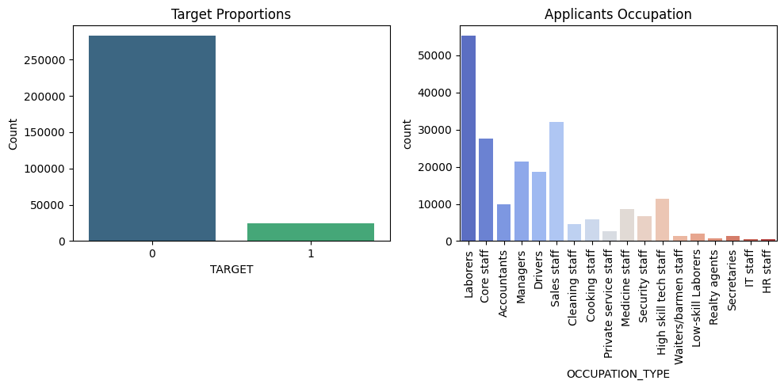

```python
import matplotlib.pyplot as plt
import seaborn as sns

fig, axes = plt.subplots(1, 2, figsize=(10, 5))  # Adjust figsize to control overall plot size

# 1. Target proportions in Application Train
sns.countplot(x=datasets["application_train"]['TARGET'], ax=axes[0], palette='viridis')
axes[0].set_title("Target Proportions")
axes[0].set_xlabel("TARGET")
axes[0].set_ylabel("Count")

# Calculate percentages
total = datasets["application_train"]['TARGET'].shape[0]
perc_difficulties = round((datasets["application_train"]['TARGET'].loc[datasets["application_train"]['TARGET'] == 1].shape[0] / total) * 100, 2)
perc_no_difficulties = round((datasets["application_train"]['TARGET'].loc[datasets["application_train"]['TARGET'] == 0].shape[0] / total) * 100, 2)
print(f"Percentage of clients with payment difficulties: {perc_difficulties}%")
print(f"Percentage of clients with no payment difficulties: {perc_no_difficulties}%")

# 2. Applicants Occupation
sns.countplot(x='OCCUPATION_TYPE', data=datasets["application_train"], ax=axes[1], palette='coolwarm')
axes[1].set_title("Applicants Occupation")
axes[1].tick_params(axis='x', rotation=90)

plt.tight_layout()
plt.show()
```

We explore default percentages by income type, education tpe, family status and housing type. Main findings include:

- Highest default by income type were inividuals on maternity leave and those who were unemployed.
- Lowest default by education type were indviduals who hold academic degree.
- There was not a significant difference in default percentages by family status or housing type.

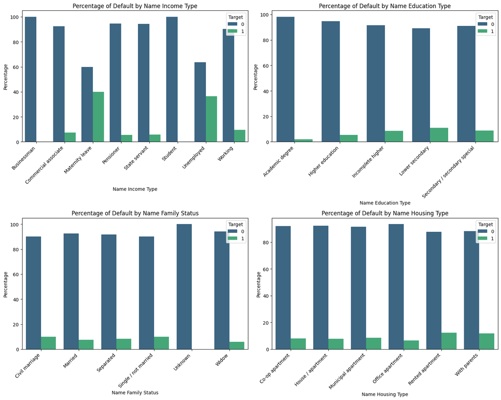

```python
import matplotlib.pyplot as plt
import seaborn as sns

# List of variables to analyze
variables = ['NAME_INCOME_TYPE', 'NAME_EDUCATION_TYPE', 'NAME_FAMILY_STATUS', 'NAME_HOUSING_TYPE']

fig, axes = plt.subplots(2, 2, figsize=(15, 12))
axes = axes.flatten()

# Loop through variables and create plots
for i, var in enumerate(variables):
    # Group by variable and TARGET, calculate the count
    grouped_data = datasets["application_train"].groupby([var, 'TARGET']).size().reset_index(name='count')

    # Normalize to calculate percentages
    grouped_data['percentage'] = grouped_data['count'] / grouped_data.groupby(var)['count'].transform('sum') * 100

    # Plot the percentage distribution of TARGET for each variable
    sns.barplot(
        data=grouped_data,
        x=var,
        y='percentage',
        hue='TARGET',
        ax=axes[i],  # Assign to the correct subplot
        palette="viridis"
    )
    axes[i].set_xticklabels(axes[i].get_xticklabels(), rotation=45, ha='right')
    axes[i].set_title(f"Percentage of Default by {var.replace('_', ' ').title()}")
    axes[i].set_ylabel("Percentage")
    axes[i].set_xlabel(var.replace('_', ' ').title())
    axes[i].legend(title="Target")

plt.tight_layout()
plt.show()
```

#### **Previous applications**

```python
pd.options.display.max_info_columns = 1
ds_name = 'previous_application'
datasets[ds_name] = load_data(os.path.join(DATA_DIR, f'{ds_name}.csv'), ds_name)
```

```
previous_application: shape is (1670214, 37)
<class 'pandas.core.frame.DataFrame'>
RangeIndex: 1670214 entries, 0 to 1670213
Columns: 37 entries, SK_ID_PREV to NFLAG_INSURED_ON_APPROVAL
dtypes: float64(15), int64(6), object(16)
memory usage: 471.5+ MB
None
```

|  | SK_ID_PREV | SK_ID_CURR | NAME_CONTRACT_TYPE | AMT_ANNUITY | AMT_APPLICATION | AMT_CREDIT | AMT_DOWN_PAYMENT | AMT_GOODS_PRICE | WEEKDAY_APPR_PROCESS_START | HOUR_APPR_PROCESS_START | ... | NAME_SELLER_INDUSTRY | CNT_PAYMENT | NAME_YIELD_GROUP | PRODUCT_COMBINATION | DAYS_FIRST_DRAWING | DAYS_FIRST_DUE | DAYS_LAST_DUE_1ST_VERSION | DAYS_LAST_DUE | DAYS_TERMINATION | NFLAG_INSURED_ON_APPROVAL |
| --- | --- | --- | --- | --- | --- | --- | --- | --- | --- | --- | --- | --- | --- | --- | --- | --- | --- | --- | --- | --- | --- |
| 0 | 2030495 | 271877 | Consumer loans | 1730.430 | 17145.0 | 17145.0 | 0.0 | 17145.0 | SATURDAY | 15 | ... | Connectivity | 12.0 | middle | POS mobile with interest | 365243.0 | -42.0 | 300.0 | -42.0 | -37.0 | 0.0 |
| 1 | 2802425 | 108129 | Cash loans | 25188.615 | 607500.0 | 679671.0 | NaN | 607500.0 | THURSDAY | 11 | ... | XNA | 36.0 | low_action | Cash X-Sell: low | 365243.0 | -134.0 | 916.0 | 365243.0 | 365243.0 | 1.0 |
| 2 | 2523466 | 122040 | Cash loans | 15060.735 | 112500.0 | 136444.5 | NaN | 112500.0 | TUESDAY | 11 | ... | XNA | 12.0 | high | Cash X-Sell: high | 365243.0 | -271.0 | 59.0 | 365243.0 | 365243.0 | 1.0 |
| 3 | 2819243 | 176158 | Cash loans | 47041.335 | 450000.0 | 470790.0 | NaN | 450000.0 | MONDAY | 7 | ... | XNA | 12.0 | middle | Cash X-Sell: middle | 365243.0 | -482.0 | -152.0 | -182.0 | -177.0 | 1.0 |
| 4 | 1784265 | 202054 | Cash loans | 31924.395 | 337500.0 | 404055.0 | NaN | 337500.0 | THURSDAY | 9 | ... | XNA | 24.0 | high | Cash Street: high | NaN | NaN | NaN | NaN | NaN | NaN |

5 rows × 37 columns

We differentiate applications by low, medium and high number of preevious claims.

- Low < 5 claims
- Medium = 5 to 39 claims
- High > 40 claims

```python
# Calculate total unique applications
prevApps = datasets["previous_application"]
apps_all = prevApps['SK_ID_CURR'].nunique()

# Count the number of previous applications per unique applicant
app_counts = prevApps['SK_ID_CURR'].value_counts()

# Define categories based on the number of previous applications
low_apps = app_counts < 5
medium_apps = (app_counts >= 5) & (app_counts < 40)
high_apps = app_counts >= 40

# Calculate percentages for each category
low_percentage = np.round(100. * sum(low_apps) / apps_all, 2)
medium_percentage = np.round(100. * sum(medium_apps) / apps_all, 2)
high_percentage = np.round(100. * sum(high_apps) / apps_all, 2)

print(f'Percentage with less than 5 previous apps (Low): {low_percentage}%')
print(f'Percentage with 5 to 39 previous apps (Medium): {medium_percentage}%')
print(f'Percentage with 40 or more previous apps (High): {high_percentage}%')
```

```
Percentage with less than 5 previous apps (Low): 58.23%
Percentage with 5 to 39 previous apps (Medium): 41.73%
Percentage with 40 or more previous apps (High): 0.03%
```

#### **Bureau and Bureau Balance**

```python
pd.options.display.max_info_columns = 1
ds_name = 'bureau'
datasets[ds_name] = load_data(os.path.join(DATA_DIR, f'{ds_name}.csv'), ds_name)
```

```
bureau: shape is (1716428, 17)
<class 'pandas.core.frame.DataFrame'>
RangeIndex: 1716428 entries, 0 to 1716427
Columns: 17 entries, SK_ID_CURR to AMT_ANNUITY
dtypes: float64(8), int64(6), object(3)
memory usage: 222.6+ MB
None
```

|  | SK_ID_CURR | SK_ID_BUREAU | CREDIT_ACTIVE | CREDIT_CURRENCY | DAYS_CREDIT | CREDIT_DAY_OVERDUE | DAYS_CREDIT_ENDDATE | DAYS_ENDDATE_FACT | AMT_CREDIT_MAX_OVERDUE | CNT_CREDIT_PROLONG | AMT_CREDIT_SUM | AMT_CREDIT_SUM_DEBT | AMT_CREDIT_SUM_LIMIT | AMT_CREDIT_SUM_OVERDUE | CREDIT_TYPE | DAYS_CREDIT_UPDATE | AMT_ANNUITY |
| --- | --- | --- | --- | --- | --- | --- | --- | --- | --- | --- | --- | --- | --- | --- | --- | --- | --- |
| 0 | 215354 | 5714462 | Closed | currency 1 | -497 | 0 | -153.0 | -153.0 | NaN | 0 | 91323.0 | 0.0 | NaN | 0.0 | Consumer credit | -131 | NaN |
| 1 | 215354 | 5714463 | Active | currency 1 | -208 | 0 | 1075.0 | NaN | NaN | 0 | 225000.0 | 171342.0 | NaN | 0.0 | Credit card | -20 | NaN |
| 2 | 215354 | 5714464 | Active | currency 1 | -203 | 0 | 528.0 | NaN | NaN | 0 | 464323.5 | NaN | NaN | 0.0 | Consumer credit | -16 | NaN |
| 3 | 215354 | 5714465 | Active | currency 1 | -203 | 0 | NaN | NaN | NaN | 0 | 90000.0 | NaN | NaN | 0.0 | Credit card | -16 | NaN |
| 4 | 215354 | 5714466 | Active | currency 1 | -629 | 0 | 1197.0 | NaN | 77674.5 | 0 | 2700000.0 | NaN | NaN | 0.0 | Consumer credit | -21 | NaN |

```python
pd.options.display.max_info_columns = 1
ds_name = 'bureau_balance'
datasets[ds_name] = load_data(os.path.join(DATA_DIR, f'{ds_name}.csv'), ds_name)
```

```
bureau_balance: shape is (27299925, 3)
<class 'pandas.core.frame.DataFrame'>
RangeIndex: 27299925 entries, 0 to 27299924
Columns: 3 entries, SK_ID_BUREAU to STATUS
dtypes: int64(2), object(1)
memory usage: 624.8+ MB
None
```

|  | SK_ID_BUREAU | MONTHS_BALANCE | STATUS |
| --- | --- | --- | --- |
| 0 | 5715448 | 0 | C |
| 1 | 5715448 | -1 | C |
| 2 | 5715448 | -2 | C |
| 3 | 5715448 | -3 | C |
| 4 | 5715448 | -4 | C |

The most commom credt types for the bureau data were consumer credit, followed by credit card.

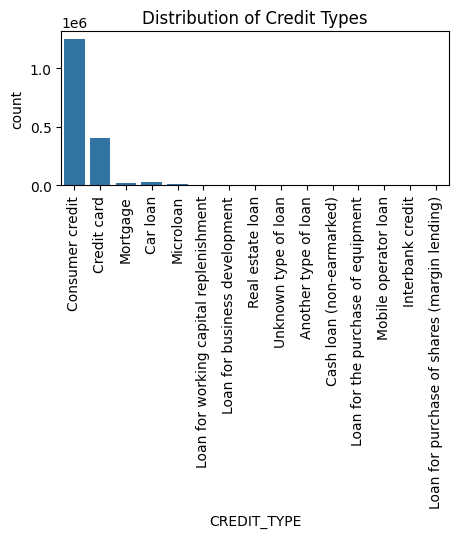

```python
bureau = datasets['bureau']

# Distribution of Credit Types
plt.figure(figsize=(5, 2))
sns.countplot(data=bureau, x='CREDIT_TYPE')
plt.title('Distribution of Credit Types')
plt.xticks(rotation=90)
plt.show()
```

#### **Credit Card Balance**

```python
pd.options.display.max_info_columns = 1
ds_name = 'credit_card_balance'
datasets[ds_name] = load_data(os.path.join(DATA_DIR, f'{ds_name}.csv'), ds_name)
```

```
credit_card_balance: shape is (3840312, 23)
<class 'pandas.core.frame.DataFrame'>
RangeIndex: 3840312 entries, 0 to 3840311
Columns: 23 entries, SK_ID_PREV to SK_DPD_DEF
dtypes: float64(15), int64(7), object(1)
memory usage: 673.9+ MB
None
```

|  | SK_ID_PREV | SK_ID_CURR | MONTHS_BALANCE | AMT_BALANCE | AMT_CREDIT_LIMIT_ACTUAL | AMT_DRAWINGS_ATM_CURRENT | AMT_DRAWINGS_CURRENT | AMT_DRAWINGS_OTHER_CURRENT | AMT_DRAWINGS_POS_CURRENT | AMT_INST_MIN_REGULARITY | ... | AMT_RECIVABLE | AMT_TOTAL_RECEIVABLE | CNT_DRAWINGS_ATM_CURRENT | CNT_DRAWINGS_CURRENT | CNT_DRAWINGS_OTHER_CURRENT | CNT_DRAWINGS_POS_CURRENT | CNT_INSTALMENT_MATURE_CUM | NAME_CONTRACT_STATUS | SK_DPD | SK_DPD_DEF |
| --- | --- | --- | --- | --- | --- | --- | --- | --- | --- | --- | --- | --- | --- | --- | --- | --- | --- | --- | --- | --- | --- |
| 0 | 2562384 | 378907 | -6 | 56.970 | 135000 | 0.0 | 877.5 | 0.0 | 877.5 | 1700.325 | ... | 0.000 | 0.000 | 0.0 | 1 | 0.0 | 1.0 | 35.0 | Active | 0 | 0 |
| 1 | 2582071 | 363914 | -1 | 63975.555 | 45000 | 2250.0 | 2250.0 | 0.0 | 0.0 | 2250.000 | ... | 64875.555 | 64875.555 | 1.0 | 1 | 0.0 | 0.0 | 69.0 | Active | 0 | 0 |
| 2 | 1740877 | 371185 | -7 | 31815.225 | 450000 | 0.0 | 0.0 | 0.0 | 0.0 | 2250.000 | ... | 31460.085 | 31460.085 | 0.0 | 0 | 0.0 | 0.0 | 30.0 | Active | 0 | 0 |
| 3 | 1389973 | 337855 | -4 | 236572.110 | 225000 | 2250.0 | 2250.0 | 0.0 | 0.0 | 11795.760 | ... | 233048.970 | 233048.970 | 1.0 | 1 | 0.0 | 0.0 | 10.0 | Active | 0 | 0 |
| 4 | 1891521 | 126868 | -1 | 453919.455 | 450000 | 0.0 | 11547.0 | 0.0 | 11547.0 | 22924.890 | ... | 453919.455 | 453919.455 | 0.0 | 1 | 0.0 | 1.0 | 101.0 | Active | 0 | 0 |

5 rows × 23 columns

The following is a plot of recency for each applcation from the credt_card_balance data. Most applications are recent.

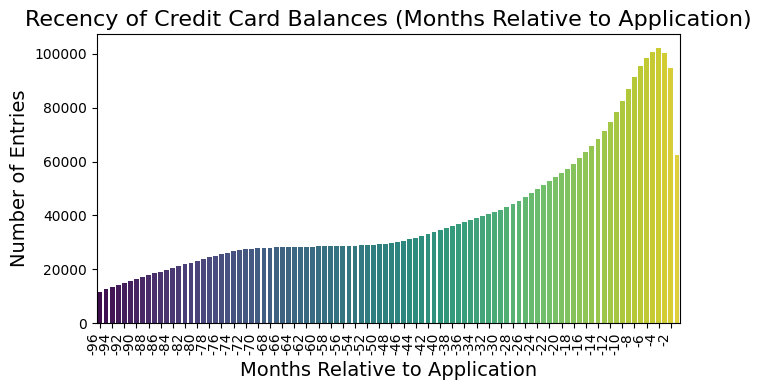

```python
ccb = datasets['credit_card_balance']

# Count occurrences of each MONTHS_BALANCE value
month_counts = ccb['MONTHS_BALANCE'].value_counts().sort_index()

# Plot the distribution of RECENCY
plt.figure(figsize=(7, 4))
sns.barplot(x=month_counts.index, y=month_counts.values, palette='viridis')

plt.title('Recency of Credit Card Balances (Months Relative to Application)', fontsize=16)
plt.xlabel('Months Relative to Application', fontsize=14)
plt.ylabel('Number of Entries', fontsize=14)

plt.xticks(ticks=range(0, len(month_counts), 2), rotation=90, ha='right')

plt.tight_layout()

plt.show()
```

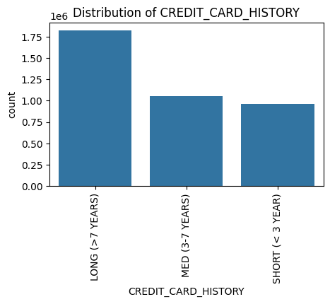

```python
# Categorize credit card history
ccb_history_months = ccb['SK_ID_CURR'].value_counts()

def categorize_history(months):
    if months < 36:
        return 'SHORT (< 3 YEAR)'
    elif 36 <= months <= 84:
        return 'MED (3-7 YEARS)'
    else:
        return 'LONG (>7 YEARS)'

ccb['CREDIT_CARD_HISTORY'] = ccb['SK_ID_CURR'].map(ccb_history_months).apply(categorize_history)
category_order = ['LONG (>7 YEARS)', 'MED (3-7 YEARS)', 'SHORT (< 3 YEAR)']

plt.figure(figsize=(5, 3))
sns.countplot(data=ccb, x='CREDIT_CARD_HISTORY', order=category_order)
plt.title('Distribution of CREDIT_CARD_HISTORY')
plt.xticks(rotation=90)
plt.show()
```

#### **Installments Payments**

```python
pd.options.display.max_info_columns = 1
ds_name = 'installments_payments'
datasets[ds_name] = load_data(os.path.join(DATA_DIR, f'{ds_name}.csv'), ds_name)
```

```
installments_payments: shape is (13605401, 8)
<class 'pandas.core.frame.DataFrame'>
RangeIndex: 13605401 entries, 0 to 13605400
Columns: 8 entries, SK_ID_PREV to AMT_PAYMENT
dtypes: float64(5), int64(3)
memory usage: 830.4 MB
None
```

|  | SK_ID_PREV | SK_ID_CURR | NUM_INSTALMENT_VERSION | NUM_INSTALMENT_NUMBER | DAYS_INSTALMENT | DAYS_ENTRY_PAYMENT | AMT_INSTALMENT | AMT_PAYMENT |
| --- | --- | --- | --- | --- | --- | --- | --- | --- |
| 0 | 1054186 | 161674 | 1.0 | 6 | -1180.0 | -1187.0 | 6948.360 | 6948.360 |
| 1 | 1330831 | 151639 | 0.0 | 34 | -2156.0 | -2156.0 | 1716.525 | 1716.525 |
| 2 | 2085231 | 193053 | 2.0 | 1 | -63.0 | -63.0 | 25425.000 | 25425.000 |
| 3 | 2452527 | 199697 | 1.0 | 3 | -2418.0 | -2426.0 | 24350.130 | 24350.130 |
| 4 | 2714724 | 167756 | 1.0 | 2 | -1383.0 | -1366.0 | 2165.040 | 2160.585 |

The histograms below illustrate the distribution of scheduled installment dates (DAYS_INSTALMENT) and actual payment dates (DAYS_ENTRY_PAYMENT) relative to the application date of the loan. These plots provide insights into the overall payment behavior of clients, including the frequency of timely payments and delayed payments, as well as how far in advance or after the scheduled date payments are made. A negative value represents days before the loan application date.

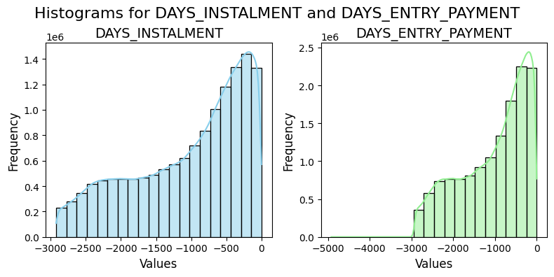

```python
import matplotlib.pyplot as plt
import seaborn as sns

installments_payments = datasets['installments_payments']

# Plot histogram for DAYS_INSTALMENT
fig, axes = plt.subplots(1, 2, figsize=(8, 4))
sns.histplot(installments_payments["DAYS_INSTALMENT"], bins=20, kde=True, color='skyblue', ax=axes[0])
axes[0].set_title("DAYS_INSTALMENT", fontsize=14)
axes[0].set_xlabel("Values", fontsize=12)
axes[0].set_ylabel("Frequency", fontsize=12)

# Plot histogram for DAYS_ENTRY_PAYMENT
sns.histplot(installments_payments["DAYS_ENTRY_PAYMENT"], bins=20, kde=True, color='lightgreen', ax=axes[1])
axes[1].set_title("DAYS_ENTRY_PAYMENT", fontsize=14)
axes[1].set_xlabel("Values", fontsize=12)
axes[1].set_ylabel("Frequency", fontsize=12)

plt.suptitle("Histograms for DAYS_INSTALMENT and DAYS_ENTRY_PAYMENT", fontsize=16)
plt.tight_layout()
plt.subplots_adjust(top=0.85)
plt.show()
```

#### **POS Cash balance**

```python
pd.options.display.max_info_columns = 1
ds_name = 'POS_CASH_balance'
datasets[ds_name] = load_data(os.path.join(DATA_DIR, f'{ds_name}.csv'), ds_name)
```

```
POS_CASH_balance: shape is (10001358, 8)
<class 'pandas.core.frame.DataFrame'>
RangeIndex: 10001358 entries, 0 to 10001357
Columns: 8 entries, SK_ID_PREV to SK_DPD_DEF
dtypes: float64(2), int64(5), object(1)
memory usage: 610.4+ MB
None
```

|  | SK_ID_PREV | SK_ID_CURR | MONTHS_BALANCE | CNT_INSTALMENT | CNT_INSTALMENT_FUTURE | NAME_CONTRACT_STATUS | SK_DPD | SK_DPD_DEF |
| --- | --- | --- | --- | --- | --- | --- | --- | --- |
| 0 | 1803195 | 182943 | -31 | 48.0 | 45.0 | Active | 0 | 0 |
| 1 | 1715348 | 367990 | -33 | 36.0 | 35.0 | Active | 0 | 0 |
| 2 | 1784872 | 397406 | -32 | 12.0 | 9.0 | Active | 0 | 0 |
| 3 | 1903291 | 269225 | -35 | 48.0 | 42.0 | Active | 0 | 0 |
| 4 | 2341044 | 334279 | -35 | 36.0 | 35.0 | Active | 0 | 0 |

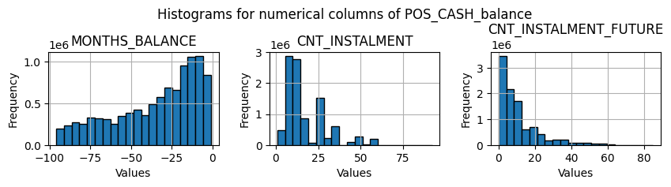

```python
pos_cash = datasets['POS_CASH_balance']
%matplotlib inline
# Create a histogram for MONTHS_BALANCE, CNT_INSTALMENT and CNT_INSTALMENT_FUTURE
pos_cash[['MONTHS_BALANCE', 'CNT_INSTALMENT','CNT_INSTALMENT_FUTURE']].hist(bins=20, figsize=(10, 2), layout=(1, 3), edgecolor="black")

plt.suptitle("Histograms for numerical columns of POS_CASH_balance", fontsize=12)
plt.subplots_adjust(top=0.7)

for ax, column_name in zip(plt.gcf().axes, ["MONTHS_BALANCE", "CNT_INSTALMENT", "CNT_INSTALMENT_FUTURE", "SKD_DPD", "SKD_DPD_DEF"]):
    ax.set_title(column_name)
    ax.set_xlabel("Values")
    ax.set_ylabel("Frequency")

plt.show()
```

### **3.4 Modeling Pipeline without Neural Networks**

**Modeling Approach**

To effectively predict loan default risk, we implemented a structured modeling process that evaluated multiple machine learning algorithms, explored feature selection techniques, and conducted hyperparameter tuning. Below, we outline our methodology and findings, including descriptions of the models and the metrics used for evaluation.

**Modeling Process**

1. **Feature Engineering and Final Dataset Creation**:
   - **Feature Engineering:** Based on insights from Exploratory Data Analysis (EDA) and business understanding, we engineered new features to enhance predictive power.
   - **Dataset Aggregation:** Aggregated features from secondary datasets using custom functions designed to summarize information effectively.
   - **Pipeline Creation:** Developed a pipeline for categorical and numerical features. Categorical features were encoded, and numerical features were aggregated using statistical functions such as mean, sum, and max.
   - **Dataset Merging:** Merged all secondary datasets with the primary application dataset using a left join on SK_ID_CURR. Each merge added new aggregated features to the dataset, resulting in a comprehensive and unified dataset.
   - **Data Transformation:** Handled missing and infinite values by replacin [np.inf, -np.inf] with np.nan.
   - **Split the dataset** into X_train, X_test, and X_valid.
   - **Label Assignment:** The target variable (y_train) was assigned as the TARGET column from X_train.
1. **Baseline Model:** Logistic Regression was chosen as a baseline due to its simplicity, interpretability, and effectiveness for binary classification tasks.
2. **Full Feature Set Models:** Initial experiments included running Logistic Regression, Decision Trees, Random Forests, Gradient Boosting, XGBoost, and LightGBM on all 208 features.
3. **Feature Selection:** To reduce dimensionality and improve interpretability, we employed:
   - **Correlation analysis** to remove highly correlated features.
   - **Feature importance** scores from **Decision Trees** and **Random Forests**.
   - **Principal Component Analysis (PCA)** to retain components explaining 95% of variance.

   **This process reduced the dataset to 20 features, which were used in subsequent experiments.**
4. **Reduced Feature Set Models:** The same models were re-trained on the reduced dataset, including Support Vector Machines (SVC) due to its efficiency with fewer features.
5. **Ensemble Models:**
   - A voting classifier (soft voting) averaged class probabilities across models.
   - A stacking classifier used predictions from all models as input features to a meta-model.
6. **Hyperparameter Tuning:** Focused on XGBoost, our best-performing model, using the reduced feature set. Parameters tuned included:
   - learning_rate
   - max_depth
   - subsample
   - colsample_bytree
7. **Performance Metrics:** We evaluated models using Accuracy, Precision, Recall, F1 Score, AUC-ROC, and Log Loss to capture different aspects of performance.

**Model Description**

These models were selected for their suitability for binary classification tasks and ability to handle large, diverse datasets with a mix of categorical and numerical features.

| Algorithm | Implementation | Loss Function |
| --- | --- | --- |
| Logistic Regression | `sklearn.linear_model.LogisticRegression` | Log Loss (Binary Cross-Entropy) |
| Decision Tree Classifier | `sklearn.tree.DecisionTreeClassifier` | Gini Impurity / Entropy |
| Random Forest | `sklearn.ensemble.RandomForestClassifier` | Gini Impurity / Entropy |
| Support Vector Machine | `sklearn.svm.SVC` | Hinge Loss (SVM Loss) |
| Gradient Boosting | `sklearn.ensemble.GradientBoostingClassifier` | Log Loss (Binary Cross-Entropy) |
| Extreme Gradient Boosting | `xgboost.XGBClassifier` | Log Loss (Binary Cross-Entropy) |
| Light Gradient Boosting | `lightgbm.LGBMClassifier` | Log Loss (Binary Cross-Entropy) |
| Voting Classifier | `sklearn.ensemble.VotingClassifier` | Weighted Average of Component Losses |
| Stacking Classifier | `sklearn.ensemble.StackingClassifier` | Meta-Model Loss |

- **Logistic Regression:** A straightforward and interpretable model for binary classification, used as a baseline to evaluate the performance of more advanced models.
- **Decision Tree Classifier:** Creates interpretable decision pathways by splitting on features. Helps understand which specific features indicate repayment likelihood.
- **Random Forest:** An ensemble of decision trees, offering robustness to overfitting and capturing complex, non-linear feature interactions.
- **Support Vector Machine (SVM):** Finds the optimal hyperplane for class separation, making it effective for high-dimensional feature spaces.
- **Gradient Boosting:** Sequentially builds models to correct the errors of prior models. Effective for structured data with complex, non-linear relationships.
- **Extreme Gradient Boosting (XGBoost):** An optimized version of gradient boosting with advanced features like regularization, missing value handling, and parallel processing for scalability.
- **Light Gradient Boosting (LightGBM):** Designed for speed and memory efficiency, handles large datasets and high-cardinality categorical features while being robust to overfitting.
- **Voting Classifier:** Combines predictions from multiple models using a soft voting strategy, leveraging the strengths of each model for improved performance.
- **Stacking Classifier:** Uses a meta-model to combine the outputs of several base models, often leading to better generalization by exploiting model complementarities.

**Model Evaluation**

To evaluate our models for the HCDR dataset, we are using accuracy, precision, recall, F1 score, AUC-ROC, and log loss metrics, which are common metrics used to evaluate classification models. The table below contains a description and formula for each metric.

| Name | Description | Formula |
| --- | --- | --- |
| Accuracy | Proportion of correctly predicted samples out of the total samples | $$\text{Accuracy} = \frac{\text{True Positives + True Negatives}}{\text{True Positives + True Negatives + False Positives + False Negatives}}$$ |
| Precision | Proportion of true positive predictions out of all positive predictions | $$\text{Precision} = \frac{\text{True Positives}}{\text{True Positives} + \text{False Positives}}$$ |
| Recall (Sensitivity) | Proportion of actual positives correctly identified | $$\text{Recall} = \frac{\text{True Positives}}{\text{True Positives} + \text{False Negatives}}$$ |
| F1 Score | Harmonic mean of precision and recall, balancing the two metrics | $$\text{F1 Score} = 2 \cdot \frac{\text{Precision} \times \text{Recall}}{\text{Precision} + \text{Recall}}$$ |
| AUC-ROC | Area under the Receiver Operating Characteristic curve, measuring model's ability to distinguish between classes | $$\text{AUC-ROC} = \int \text{ROC Curve}$$ |
| Log Loss | Logarithmic loss penalizes wrong predictions more as they deviate from true class probabilities | $$\text{Log Loss} = -\frac{1}{m} \sum_{i=1}^{m} \sum_{k=1}^{K} y_k^{(i)} \log(\hat{p}_k^{(i)})$$ |

- **Accuracy** is the proportion of correctly predicted values divided by the total number of predicted values. It basically measures how often a machine learning model correctly predicts the outcome. This metric doesn't work well if the data set is imbalanced, meaning the overwhelming majority of the Target variables have the same classification.
- **Precision** is the proportion of true positive values predicted to the total number of positive values predicted. For projects where false positives are less desirable, precision is a good metric choice to minimize them.
- **Recall** is the proportion of true positive values predicted to the total number of the true positives and the total number of the false negatives. For projects where false negatives are less desirable, recall is a good metric choice.
- **F1 Score** is the harmonic mean of precision and recall. For projects where both false positives and false negatives are similarly weighted then F1 is a good metric choice.
- **AUC-ROC** is Area under the Receiver Operating Characteristic curve which measures a model's ability to distinguish between classes. AUC-ROC is a good metric choice for projects with highly imbalanced data sets.
- **Log (Logarithmic) loss** penalizes wrong predictions more as they deviate from true class probabilities. Log loss is a good metric choice for balanced and imbalanced data sets but can be sensitive to outliers.

### **3.4.1. Feature Engineering and Dataset Aggregation**

In this project, aggregation was a critical step because many of the datasets were provided at a level that did not align with the unique identifier of the loan applications (`SK_ID_CURR`). For example, data such as installment payments, credit card balances, and POS loans contained multiple entries, representing either monthly snapshots or transaction records. This misalignment required us to summarize these datasets at the `SK_ID_CURR` level to effectively integrate them into the primary dataset and make them usable for predictive modeling. Additionally, new features were engineered during aggregation.

The **prevAppsFeaturesAggregater** function handled the *previous_application* dataset, which included historical loan applications with multiple rows per client. Aggregation was performed using statistical functions such as min, max, and mean on numeric features like `AMT_APPLICATION` and `AMT_ANNUITY`. A new feature, `range_AMT_APPLICATION`, was created to represent the variability in requested loan amounts. This variability is meaningful for predicting whether a client is likely to repay because it provides insight into the consistency or fluctuation in their financial needs over time.

The **POSCashBalanceFeaturesAggregater** function aggregated the *POS_CASH_balance* dataset, which tracked the status of POS and cash loans. This dataset included fields such as `SK_DPD` (days past due) and `CNT_INSTALMENT_FUTURE` (remaining installments). New features, like `POS_REMAINING_INSTALMENTS_RATIO`, which calculated the ratio of remaining installments to total installments, were engineered to highlight repayment progress.

#### **Previous applications table aggregation**

```python
ds_name = 'previous_application'
datasets[ds_name] = load_data(os.path.join(DATA_DIR, f'{ds_name}.csv'), ds_name)
appsDF = datasets["previous_application"]
display(appsDF.head())
print(f"{appsDF.shape[0]:,} rows, {appsDF.shape[1]:,} columns")
print(f"There are  {appsDF.shape[0]:,} previous applications")
print(f'Number of train applicants with previous applications is {len(np.intersect1d(datasets["previous_application"]["SK_ID_CURR"], datasets["application_train"]["SK_ID_CURR"])):,}')
print(f'Number of train applicants with previous applications is {len(np.intersect1d(datasets["previous_application"]["SK_ID_CURR"], datasets["application_test"]["SK_ID_CURR"])):,}')
```

```
previous_application: shape is (1670214, 37)
<class 'pandas.core.frame.DataFrame'>
RangeIndex: 1670214 entries, 0 to 1670213
Columns: 37 entries, SK_ID_PREV to NFLAG_INSURED_ON_APPROVAL
dtypes: float64(15), int64(6), object(16)
memory usage: 471.5+ MB
None
```

|  | SK_ID_PREV | SK_ID_CURR | NAME_CONTRACT_TYPE | AMT_ANNUITY | AMT_APPLICATION | AMT_CREDIT | AMT_DOWN_PAYMENT | AMT_GOODS_PRICE | WEEKDAY_APPR_PROCESS_START | HOUR_APPR_PROCESS_START | ... | NAME_SELLER_INDUSTRY | CNT_PAYMENT | NAME_YIELD_GROUP | PRODUCT_COMBINATION | DAYS_FIRST_DRAWING | DAYS_FIRST_DUE | DAYS_LAST_DUE_1ST_VERSION | DAYS_LAST_DUE | DAYS_TERMINATION | NFLAG_INSURED_ON_APPROVAL |
| --- | --- | --- | --- | --- | --- | --- | --- | --- | --- | --- | --- | --- | --- | --- | --- | --- | --- | --- | --- | --- | --- |
| 0 | 2030495 | 271877 | Consumer loans | 1730.430 | 17145.0 | 17145.0 | 0.0 | 17145.0 | SATURDAY | 15 | ... | Connectivity | 12.0 | middle | POS mobile with interest | 365243.0 | -42.0 | 300.0 | -42.0 | -37.0 | 0.0 |
| 1 | 2802425 | 108129 | Cash loans | 25188.615 | 607500.0 | 679671.0 | NaN | 607500.0 | THURSDAY | 11 | ... | XNA | 36.0 | low_action | Cash X-Sell: low | 365243.0 | -134.0 | 916.0 | 365243.0 | 365243.0 | 1.0 |
| 2 | 2523466 | 122040 | Cash loans | 15060.735 | 112500.0 | 136444.5 | NaN | 112500.0 | TUESDAY | 11 | ... | XNA | 12.0 | high | Cash X-Sell: high | 365243.0 | -271.0 | 59.0 | 365243.0 | 365243.0 | 1.0 |
| 3 | 2819243 | 176158 | Cash loans | 47041.335 | 450000.0 | 470790.0 | NaN | 450000.0 | MONDAY | 7 | ... | XNA | 12.0 | middle | Cash X-Sell: middle | 365243.0 | -482.0 | -152.0 | -182.0 | -177.0 | 1.0 |
| 4 | 1784265 | 202054 | Cash loans | 31924.395 | 337500.0 | 404055.0 | NaN | 337500.0 | THURSDAY | 9 | ... | XNA | 24.0 | high | Cash Street: high | NaN | NaN | NaN | NaN | NaN | NaN |

5 rows × 37 columns

|  | SK_ID_PREV | SK_ID_CURR | NAME_CONTRACT_TYPE | AMT_ANNUITY | AMT_APPLICATION | AMT_CREDIT | AMT_DOWN_PAYMENT | AMT_GOODS_PRICE | WEEKDAY_APPR_PROCESS_START | HOUR_APPR_PROCESS_START | ... | NAME_SELLER_INDUSTRY | CNT_PAYMENT | NAME_YIELD_GROUP | PRODUCT_COMBINATION | DAYS_FIRST_DRAWING | DAYS_FIRST_DUE | DAYS_LAST_DUE_1ST_VERSION | DAYS_LAST_DUE | DAYS_TERMINATION | NFLAG_INSURED_ON_APPROVAL |
| --- | --- | --- | --- | --- | --- | --- | --- | --- | --- | --- | --- | --- | --- | --- | --- | --- | --- | --- | --- | --- | --- |
| 0 | 2030495 | 271877 | Consumer loans | 1730.430 | 17145.0 | 17145.0 | 0.0 | 17145.0 | SATURDAY | 15 | ... | Connectivity | 12.0 | middle | POS mobile with interest | 365243.0 | -42.0 | 300.0 | -42.0 | -37.0 | 0.0 |
| 1 | 2802425 | 108129 | Cash loans | 25188.615 | 607500.0 | 679671.0 | NaN | 607500.0 | THURSDAY | 11 | ... | XNA | 36.0 | low_action | Cash X-Sell: low | 365243.0 | -134.0 | 916.0 | 365243.0 | 365243.0 | 1.0 |
| 2 | 2523466 | 122040 | Cash loans | 15060.735 | 112500.0 | 136444.5 | NaN | 112500.0 | TUESDAY | 11 | ... | XNA | 12.0 | high | Cash X-Sell: high | 365243.0 | -271.0 | 59.0 | 365243.0 | 365243.0 | 1.0 |
| 3 | 2819243 | 176158 | Cash loans | 47041.335 | 450000.0 | 470790.0 | NaN | 450000.0 | MONDAY | 7 | ... | XNA | 12.0 | middle | Cash X-Sell: middle | 365243.0 | -482.0 | -152.0 | -182.0 | -177.0 | 1.0 |
| 4 | 1784265 | 202054 | Cash loans | 31924.395 | 337500.0 | 404055.0 | NaN | 337500.0 | THURSDAY | 9 | ... | XNA | 24.0 | high | Cash Street: high | NaN | NaN | NaN | NaN | NaN | NaN |

5 rows × 37 columns

```
1,670,214 rows, 37 columns
There are  1,670,214 previous applications
Number of train applicants with previous applications is 291,057
Number of train applicants with previous applications is 47,800
```

```python
# Create aggregate features (via pipeline)
class prevAppsFeaturesAggregater(BaseEstimator, TransformerMixin):
    def __init__(self, features=None): # no *args or **kargs
        self.features = features
        self.agg_op_features = {}
        for f in features:
            #self.agg_op_features[f] = {f"{f}_{func}":func for func in ["min", "max", "mean"]}
            self.agg_op_features[f] = ['min', 'max', 'mean']

    def fit(self, X, y=None):
        return self

    def transform(self, X, y=None):
        #from IPython.core.debugger import Pdb as pdb;    pdb().set_trace() #breakpoint; dont forget to quit
        result = X.groupby(["SK_ID_CURR"]).agg(self.agg_op_features)
        result.columns = ['_'.join(col).strip() for col in result.columns]
        #result.columns = result.columns.droplevel()
        result = result.reset_index(level=["SK_ID_CURR"])
        result['range_AMT_APPLICATION'] = result['AMT_APPLICATION_max'] - result['AMT_APPLICATION_min']
        return result # return dataframe with the join key "SK_ID_CURR"


from sklearn.pipeline import make_pipeline
def test_driver_prevAppsFeaturesAggregater(df, features):
    print(f"df.shape: {df.shape}\n")
    print(f"df[{features}][0:5]: \n{df[features][0:5]}")
    test_pipeline = make_pipeline(prevAppsFeaturesAggregater(features))
    return(test_pipeline.fit_transform(df))

features = ['AMT_ANNUITY', 'AMT_APPLICATION']
features = ['AMT_ANNUITY',
       'AMT_APPLICATION', 'AMT_CREDIT', 'AMT_DOWN_PAYMENT', 'AMT_GOODS_PRICE',
       'RATE_DOWN_PAYMENT', 'RATE_INTEREST_PRIMARY',
       'RATE_INTEREST_PRIVILEGED', 'DAYS_DECISION', 'NAME_PAYMENT_TYPE',
       'CNT_PAYMENT',
       'DAYS_FIRST_DRAWING', 'DAYS_FIRST_DUE', 'DAYS_LAST_DUE_1ST_VERSION',
       'DAYS_LAST_DUE', 'DAYS_TERMINATION']
features = ['AMT_ANNUITY', 'AMT_APPLICATION']
res = test_driver_prevAppsFeaturesAggregater(appsDF, features)
print(f"HELLO")
print(f"Test driver: \n{res[0:10]}")
print(f"input[features][0:10]: \n{appsDF[0:10]}")
```

```
df.shape: (1670214, 37)

df[['AMT_ANNUITY', 'AMT_APPLICATION']][0:5]:
   AMT_ANNUITY  AMT_APPLICATION
0     1730.430          17145.0
1    25188.615         607500.0
2    15060.735         112500.0
3    47041.335         450000.0
4    31924.395         337500.0
HELLO
Test driver:
   SK_ID_CURR  AMT_ANNUITY_min  AMT_ANNUITY_max  AMT_ANNUITY_mean  \
0      100001         3951.000         3951.000       3951.000000
1      100002         9251.775         9251.775       9251.775000
2      100003         6737.310        98356.995      56553.990000
```

[output cut: 105 more lines]

#### **Bureau and Bureau Balance table aggregation**

```python
ds_name = 'bureau'
datasets[ds_name] = load_data(os.path.join(DATA_DIR, f'{ds_name}.csv'), ds_name)
bureau = datasets['bureau']
bureau_features = ['AMT_CREDIT_SUM', 'AMT_CREDIT_SUM_DEBT', 'AMT_CREDIT_SUM_LIMIT','AMT_CREDIT_SUM_OVERDUE', 'AMT_ANNUITY']
class BureauFeaturesAggregater(BaseEstimator, TransformerMixin):
    def __init__(self, features=None):
      self.features = features
      self.agg_op_features = {}
      for f in features:
        self.agg_op_features[f] = ['min', 'max', 'mean']

    def fit(self, X, y=None):
      return self


    def transform(self, X, y=None):
    # Create overdue credit ratio
      sum_overdue_credit = X.groupby('SK_ID_CURR')['AMT_CREDIT_SUM_OVERDUE'].sum()
      sum_total_credit = X.groupby('SK_ID_CURR')['AMT_CREDIT_SUM'].sum()
      overdue_credit_ratio = sum_overdue_credit/sum_total_credit

      result = X.groupby('SK_ID_CURR').agg(self.agg_op_features)
      result.columns = ['_'.join(col).strip() for col in result.columns]

      result['OVERDUE_CREDIT_RATIO'] = overdue_credit_ratio

      return result


from sklearn.pipeline import make_pipeline
def test_driver_BureauFeaturesAggregater(df, features):
    print(f"df.shape: {df.shape}\n")
    print(f"df[{features}][0:5]: \n{df[features][0:5]}")
    test_pipeline = make_pipeline(BureauFeaturesAggregater(features))
    return(test_pipeline.fit_transform(df))

bureau_features = ['AMT_CREDIT_SUM', 'AMT_CREDIT_SUM_DEBT', 'AMT_CREDIT_SUM_LIMIT','AMT_CREDIT_SUM_OVERDUE', 'AMT_ANNUITY']
res = test_driver_BureauFeaturesAggregater(bureau, bureau_features)
print(f"HELLO")
print(f"Test driver: \n{res[0:10]}")
```

```
bureau: shape is (1716428, 17)
<class 'pandas.core.frame.DataFrame'>
RangeIndex: 1716428 entries, 0 to 1716427
Columns: 17 entries, SK_ID_CURR to AMT_ANNUITY
dtypes: float64(8), int64(6), object(3)
memory usage: 222.6+ MB
None
```

|  | SK_ID_CURR | SK_ID_BUREAU | CREDIT_ACTIVE | CREDIT_CURRENCY | DAYS_CREDIT | CREDIT_DAY_OVERDUE | DAYS_CREDIT_ENDDATE | DAYS_ENDDATE_FACT | AMT_CREDIT_MAX_OVERDUE | CNT_CREDIT_PROLONG | AMT_CREDIT_SUM | AMT_CREDIT_SUM_DEBT | AMT_CREDIT_SUM_LIMIT | AMT_CREDIT_SUM_OVERDUE | CREDIT_TYPE | DAYS_CREDIT_UPDATE | AMT_ANNUITY |
| --- | --- | --- | --- | --- | --- | --- | --- | --- | --- | --- | --- | --- | --- | --- | --- | --- | --- |
| 0 | 215354 | 5714462 | Closed | currency 1 | -497 | 0 | -153.0 | -153.0 | NaN | 0 | 91323.0 | 0.0 | NaN | 0.0 | Consumer credit | -131 | NaN |
| 1 | 215354 | 5714463 | Active | currency 1 | -208 | 0 | 1075.0 | NaN | NaN | 0 | 225000.0 | 171342.0 | NaN | 0.0 | Credit card | -20 | NaN |
| 2 | 215354 | 5714464 | Active | currency 1 | -203 | 0 | 528.0 | NaN | NaN | 0 | 464323.5 | NaN | NaN | 0.0 | Consumer credit | -16 | NaN |
| 3 | 215354 | 5714465 | Active | currency 1 | -203 | 0 | NaN | NaN | NaN | 0 | 90000.0 | NaN | NaN | 0.0 | Credit card | -16 | NaN |
| 4 | 215354 | 5714466 | Active | currency 1 | -629 | 0 | 1197.0 | NaN | 77674.5 | 0 | 2700000.0 | NaN | NaN | 0.0 | Consumer credit | -21 | NaN |

```
df.shape: (1716428, 17)

df[['AMT_CREDIT_SUM', 'AMT_CREDIT_SUM_DEBT', 'AMT_CREDIT_SUM_LIMIT', 'AMT_CREDIT_SUM_OVERDUE', 'AMT_ANNUITY']][0:5]:
   AMT_CREDIT_SUM  AMT_CREDIT_SUM_DEBT  AMT_CREDIT_SUM_LIMIT  \
0         91323.0                  0.0                   NaN
1        225000.0             171342.0                   NaN
2        464323.5                  NaN                   NaN
3         90000.0                  NaN                   NaN
4       2700000.0                  NaN                   NaN

   AMT_CREDIT_SUM_OVERDUE  AMT_ANNUITY
0                     0.0          NaN
1                     0.0          NaN
2                     0.0          NaN
3                     0.0          NaN
```

[output cut: 93 more lines]

```python
ID_combos = bureau[['SK_ID_CURR','SK_ID_BUREAU']].drop_duplicates()
ds_name = 'bureau_balance'
datasets[ds_name] = load_data(os.path.join(DATA_DIR, f'{ds_name}.csv'), ds_name)
bureau_balance = pd.merge(datasets['bureau_balance'], ID_combos, on='SK_ID_BUREAU', how='left')
bureau_balance_features = ['STATUS']

class BureauBalanceFeaturesAggregater(BaseEstimator, TransformerMixin):
    def __init__(self, features=None):
      self.features = features
      self.agg_op_features = {}
      for f in features:
        self.agg_op_features[f] = ['count']

    def fit(self, X, y=None):
      return self

    def transform(self, X, y=None):
    # Get counts of each loan status (Active, closed, days past due, etc.) in bureau balance table
      result = X.groupby(['SK_ID_CURR', 'STATUS']).size().unstack(fill_value=0)
      result.columns = [f'STATUS_{col}_COUNT' for col in result.columns]
      result = result.reset_index(level=['SK_ID_CURR'])
      result.fillna(0, inplace=True)
      result['SK_ID_CURR'] = result['SK_ID_CURR'].astype(int)
      return result

# Test the BureauBalanceFeaturesAggregater
def test_driver_BureauBalanceFeaturesAggregater(df, features):
    print(f"df.shape: {df.shape}\n")
    print(f"df[{features}][0:5]: \n{df[features][0:5]}")
    test_pipeline = make_pipeline(BureauBalanceFeaturesAggregater(features))
    return(test_pipeline.fit_transform(df))

bureau_balance_features = ['STATUS']
res = test_driver_BureauBalanceFeaturesAggregater(bureau_balance, bureau_balance_features)
print(f"Test driver: \n{res[0:10]}")
```

```
bureau_balance: shape is (27299925, 3)
<class 'pandas.core.frame.DataFrame'>
RangeIndex: 27299925 entries, 0 to 27299924
Columns: 3 entries, SK_ID_BUREAU to STATUS
dtypes: int64(2), object(1)
memory usage: 624.8+ MB
None
```

|  | SK_ID_BUREAU | MONTHS_BALANCE | STATUS |
| --- | --- | --- | --- |
| 0 | 5715448 | 0 | C |
| 1 | 5715448 | -1 | C |
| 2 | 5715448 | -2 | C |
| 3 | 5715448 | -3 | C |
| 4 | 5715448 | -4 | C |

```
df.shape: (27299925, 4)

df[['STATUS']][0:5]:
  STATUS
0      C
1      C
2      C
3      C
4      C
Test driver:
   SK_ID_CURR  STATUS_0_COUNT  STATUS_1_COUNT  STATUS_2_COUNT  STATUS_3_COUNT  \
0      100001              31               1               0               0
1      100002              45              27               0               0
2      100005              14               0               0               0
3      100010              20               0               0               0
```

[output cut: 18 more lines]

#### **Credit card balance aggregation**

```python
ds_name = 'credit_card_balance'
datasets[ds_name] = load_data(os.path.join(DATA_DIR, f'{ds_name}.csv'), ds_name)
```

```
credit_card_balance: shape is (3840312, 23)
<class 'pandas.core.frame.DataFrame'>
RangeIndex: 3840312 entries, 0 to 3840311
Columns: 23 entries, SK_ID_PREV to SK_DPD_DEF
dtypes: float64(15), int64(7), object(1)
memory usage: 673.9+ MB
None
```

|  | SK_ID_PREV | SK_ID_CURR | MONTHS_BALANCE | AMT_BALANCE | AMT_CREDIT_LIMIT_ACTUAL | AMT_DRAWINGS_ATM_CURRENT | AMT_DRAWINGS_CURRENT | AMT_DRAWINGS_OTHER_CURRENT | AMT_DRAWINGS_POS_CURRENT | AMT_INST_MIN_REGULARITY | ... | AMT_RECIVABLE | AMT_TOTAL_RECEIVABLE | CNT_DRAWINGS_ATM_CURRENT | CNT_DRAWINGS_CURRENT | CNT_DRAWINGS_OTHER_CURRENT | CNT_DRAWINGS_POS_CURRENT | CNT_INSTALMENT_MATURE_CUM | NAME_CONTRACT_STATUS | SK_DPD | SK_DPD_DEF |
| --- | --- | --- | --- | --- | --- | --- | --- | --- | --- | --- | --- | --- | --- | --- | --- | --- | --- | --- | --- | --- | --- |
| 0 | 2562384 | 378907 | -6 | 56.970 | 135000 | 0.0 | 877.5 | 0.0 | 877.5 | 1700.325 | ... | 0.000 | 0.000 | 0.0 | 1 | 0.0 | 1.0 | 35.0 | Active | 0 | 0 |
| 1 | 2582071 | 363914 | -1 | 63975.555 | 45000 | 2250.0 | 2250.0 | 0.0 | 0.0 | 2250.000 | ... | 64875.555 | 64875.555 | 1.0 | 1 | 0.0 | 0.0 | 69.0 | Active | 0 | 0 |
| 2 | 1740877 | 371185 | -7 | 31815.225 | 450000 | 0.0 | 0.0 | 0.0 | 0.0 | 2250.000 | ... | 31460.085 | 31460.085 | 0.0 | 0 | 0.0 | 0.0 | 30.0 | Active | 0 | 0 |
| 3 | 1389973 | 337855 | -4 | 236572.110 | 225000 | 2250.0 | 2250.0 | 0.0 | 0.0 | 11795.760 | ... | 233048.970 | 233048.970 | 1.0 | 1 | 0.0 | 0.0 | 10.0 | Active | 0 | 0 |
| 4 | 1891521 | 126868 | -1 | 453919.455 | 450000 | 0.0 | 11547.0 | 0.0 | 11547.0 | 22924.890 | ... | 453919.455 | 453919.455 | 0.0 | 1 | 0.0 | 1.0 | 101.0 | Active | 0 | 0 |

5 rows × 23 columns

```python
ds_name = 'credit_card_balance'
datasets[ds_name] = load_data(os.path.join(DATA_DIR, f'{ds_name}.csv'), ds_name)
ccb = datasets['credit_card_balance']
ccb_features = ['AMT_BALANCE', 'AMT_CREDIT_LIMIT_ACTUAL', 'AMT_DRAWINGS_CURRENT', # Reduced number of features
               'AMT_PAYMENT_TOTAL_CURRENT', 'CNT_DRAWINGS_CURRENT', 'CNT_DRAWINGS_ATM_CURRENT' ]

class CreditCardFeaturesAggregater(BaseEstimator, TransformerMixin):
    def __init__(self, features=None):
      self.features = features
      self.agg_op_features = {}
      for f in features:
        self.agg_op_features[f] = ['min', 'max', 'mean'] # Modified from 'sum' to 'min'

    def fit(self, X, y=None):
      return self

    def transform(self, X, y=None):
    # Handle missing values for the numerical features by filling with zeros
        X = X.fillna(0)

    # Create new features
        credit_util_ratio = X['AMT_BALANCE'] / X['AMT_CREDIT_LIMIT_ACTUAL']
        payment_draw_ratio = X['AMT_PAYMENT_TOTAL_CURRENT'] / X['AMT_DRAWINGS_CURRENT']
        amt_drawings_total = X['AMT_DRAWINGS_CURRENT'] + X['AMT_DRAWINGS_OTHER_CURRENT'] + X['AMT_DRAWINGS_POS_CURRENT']
        cnt_drawings_total = X['CNT_DRAWINGS_CURRENT'] + X['CNT_DRAWINGS_ATM_CURRENT'] + X['CNT_DRAWINGS_OTHER_CURRENT']
        dpd_max = X[['SK_DPD', 'SK_DPD_DEF']].max(axis=1)

    # Aggregate features at SK_ID_CURR level
        result = X.groupby('SK_ID_CURR').agg(self.agg_op_features)
        result.columns = ['_'.join(col).strip() for col in result.columns]

    # Add the newly calculated features to the aggregated result
        result['CREDIT_UTIL_RATIO'] = credit_util_ratio.groupby(X['SK_ID_CURR']).mean()
        result['PAYMENT_DRAW_RATIO'] = payment_draw_ratio.groupby(X['SK_ID_CURR']).mean()
        result['AMT_DRAWINGS_TOTAL'] = amt_drawings_total.groupby(X['SK_ID_CURR']).mean()
        result['CNT_DRAWINGS_TOTAL'] = cnt_drawings_total.groupby(X['SK_ID_CURR']).mean()
        result['DPD_MAX'] = dpd_max.groupby(X['SK_ID_CURR']).max()

        return result


from sklearn.pipeline import make_pipeline
def test_driver_CreditCardFeaturesAggregater(df, features):
    print(f"df.shape: {df.shape}\n")
    print(f"df[{features}][0:5]: \n{df[features][0:5]}")
    test_pipeline = make_pipeline(CreditCardFeaturesAggregater(features))
    return(test_pipeline.fit_transform(df))

ccb_features = ['AMT_BALANCE', 'AMT_CREDIT_LIMIT_ACTUAL', 'AMT_DRAWINGS_CURRENT', # Reduced number of features
               'AMT_PAYMENT_TOTAL_CURRENT', 'CNT_DRAWINGS_CURRENT', 'CNT_DRAWINGS_ATM_CURRENT' ]

res = test_driver_CreditCardFeaturesAggregater(ccb, ccb_features)
print(f"HELLO")
print(f"Test driver: \n{res[0:10]}")
```

```
credit_card_balance: shape is (3840312, 23)
<class 'pandas.core.frame.DataFrame'>
RangeIndex: 3840312 entries, 0 to 3840311
Columns: 23 entries, SK_ID_PREV to SK_DPD_DEF
dtypes: float64(15), int64(7), object(1)
memory usage: 673.9+ MB
None
```

|  | SK_ID_PREV | SK_ID_CURR | MONTHS_BALANCE | AMT_BALANCE | AMT_CREDIT_LIMIT_ACTUAL | AMT_DRAWINGS_ATM_CURRENT | AMT_DRAWINGS_CURRENT | AMT_DRAWINGS_OTHER_CURRENT | AMT_DRAWINGS_POS_CURRENT | AMT_INST_MIN_REGULARITY | ... | AMT_RECIVABLE | AMT_TOTAL_RECEIVABLE | CNT_DRAWINGS_ATM_CURRENT | CNT_DRAWINGS_CURRENT | CNT_DRAWINGS_OTHER_CURRENT | CNT_DRAWINGS_POS_CURRENT | CNT_INSTALMENT_MATURE_CUM | NAME_CONTRACT_STATUS | SK_DPD | SK_DPD_DEF |
| --- | --- | --- | --- | --- | --- | --- | --- | --- | --- | --- | --- | --- | --- | --- | --- | --- | --- | --- | --- | --- | --- |
| 0 | 2562384 | 378907 | -6 | 56.970 | 135000 | 0.0 | 877.5 | 0.0 | 877.5 | 1700.325 | ... | 0.000 | 0.000 | 0.0 | 1 | 0.0 | 1.0 | 35.0 | Active | 0 | 0 |
| 1 | 2582071 | 363914 | -1 | 63975.555 | 45000 | 2250.0 | 2250.0 | 0.0 | 0.0 | 2250.000 | ... | 64875.555 | 64875.555 | 1.0 | 1 | 0.0 | 0.0 | 69.0 | Active | 0 | 0 |
| 2 | 1740877 | 371185 | -7 | 31815.225 | 450000 | 0.0 | 0.0 | 0.0 | 0.0 | 2250.000 | ... | 31460.085 | 31460.085 | 0.0 | 0 | 0.0 | 0.0 | 30.0 | Active | 0 | 0 |
| 3 | 1389973 | 337855 | -4 | 236572.110 | 225000 | 2250.0 | 2250.0 | 0.0 | 0.0 | 11795.760 | ... | 233048.970 | 233048.970 | 1.0 | 1 | 0.0 | 0.0 | 10.0 | Active | 0 | 0 |
| 4 | 1891521 | 126868 | -1 | 453919.455 | 450000 | 0.0 | 11547.0 | 0.0 | 11547.0 | 22924.890 | ... | 453919.455 | 453919.455 | 0.0 | 1 | 0.0 | 1.0 | 101.0 | Active | 0 | 0 |

5 rows × 23 columns

```
df.shape: (3840312, 23)

df[['AMT_BALANCE', 'AMT_CREDIT_LIMIT_ACTUAL', 'AMT_DRAWINGS_CURRENT', 'AMT_PAYMENT_TOTAL_CURRENT', 'CNT_DRAWINGS_CURRENT', 'CNT_DRAWINGS_ATM_CURRENT']][0:5]:
   AMT_BALANCE  AMT_CREDIT_LIMIT_ACTUAL  AMT_DRAWINGS_CURRENT  \
0       56.970                   135000                 877.5
1    63975.555                    45000                2250.0
2    31815.225                   450000                   0.0
3   236572.110                   225000                2250.0
4   453919.455                   450000               11547.0

   AMT_PAYMENT_TOTAL_CURRENT  CNT_DRAWINGS_CURRENT  CNT_DRAWINGS_ATM_CURRENT
0                     1800.0                     1                       0.0
1                     2250.0                     1                       1.0
2                     2250.0                     0                       0.0
3                    11925.0                     1                       1.0
```

[output cut: 121 more lines]

#### **Installment payments aggregation**

```python
ds_name = 'installments_payments'
datasets[ds_name] = load_data(os.path.join(DATA_DIR, f'{ds_name}.csv'), ds_name)
installments_payments = datasets["installments_payments"]
```

```
installments_payments: shape is (13605401, 8)
<class 'pandas.core.frame.DataFrame'>
RangeIndex: 13605401 entries, 0 to 13605400
Columns: 8 entries, SK_ID_PREV to AMT_PAYMENT
dtypes: float64(5), int64(3)
memory usage: 830.4 MB
None
```

|  | SK_ID_PREV | SK_ID_CURR | NUM_INSTALMENT_VERSION | NUM_INSTALMENT_NUMBER | DAYS_INSTALMENT | DAYS_ENTRY_PAYMENT | AMT_INSTALMENT | AMT_PAYMENT |
| --- | --- | --- | --- | --- | --- | --- | --- | --- |
| 0 | 1054186 | 161674 | 1.0 | 6 | -1180.0 | -1187.0 | 6948.360 | 6948.360 |
| 1 | 1330831 | 151639 | 0.0 | 34 | -2156.0 | -2156.0 | 1716.525 | 1716.525 |
| 2 | 2085231 | 193053 | 2.0 | 1 | -63.0 | -63.0 | 25425.000 | 25425.000 |
| 3 | 2452527 | 199697 | 1.0 | 3 | -2418.0 | -2426.0 | 24350.130 | 24350.130 |
| 4 | 2714724 | 167756 | 1.0 | 2 | -1383.0 | -1366.0 | 2165.040 | 2160.585 |

```python
class InstallmentsFeaturesAggregater(BaseEstimator, TransformerMixin):
    def __init__(self):
        self.delay_agg_op = {
            'payment_delay_days': ['mean', 'max']  # Include average_delay and max_delay
        }
        self.payment_agg_op = {
            'amt_payment_difference': ['sum', 'std'],  # Include total_payment_difference and variability_payment_difference
            'payment_to_installment_ratio': ['mean', 'max']  # Include average_payment_ratio and max_payment_ratio
        }

    def fit(self, X, y=None):
        return self

    def transform(self, X, y=None):

        # Create new features
        X['payment_delay_days'] = X['DAYS_ENTRY_PAYMENT'] - X['DAYS_INSTALMENT']
        X['amt_payment_difference'] = X['AMT_INSTALMENT'] - X['AMT_PAYMENT']
        X['payment_to_installment_ratio'] = X['AMT_PAYMENT'] / X['AMT_INSTALMENT']

        # Aggregate delay features
        delay_features = X.groupby('SK_ID_CURR').agg(self.delay_agg_op)
        delay_features.columns = ['_'.join(col).strip() for col in delay_features.columns]

        # Aggregate payment features
        payment_features = X.groupby('SK_ID_CURR').agg(self.payment_agg_op)
        payment_features.columns = ['_'.join(col).strip() for col in payment_features.columns]

        # Combine both aggregated features
        aggregated_features = pd.concat([delay_features, payment_features], axis=1)

        return aggregated_features.reset_index()

# Test function for the updated InstallmentsFeaturesAggregater
def test_driver_InstallmentsFeaturesAggregater(df):
    print(f"df.shape: {df.shape}\n")
    print(f"Sample df columns: {df.columns}")
    test_pipeline = make_pipeline(InstallmentsFeaturesAggregater())
    result = test_pipeline.fit_transform(df)
    return result
```

#### **POS Cash balance aggregation**

```python
ds_name = 'POS_CASH_balance'
datasets[ds_name] = load_data(os.path.join(DATA_DIR, f'{ds_name}.csv'), ds_name)
pos_cash = datasets["POS_CASH_balance"]
```

```
POS_CASH_balance: shape is (10001358, 8)
<class 'pandas.core.frame.DataFrame'>
RangeIndex: 10001358 entries, 0 to 10001357
Columns: 8 entries, SK_ID_PREV to SK_DPD_DEF
dtypes: float64(2), int64(5), object(1)
memory usage: 610.4+ MB
None
```

|  | SK_ID_PREV | SK_ID_CURR | MONTHS_BALANCE | CNT_INSTALMENT | CNT_INSTALMENT_FUTURE | NAME_CONTRACT_STATUS | SK_DPD | SK_DPD_DEF |
| --- | --- | --- | --- | --- | --- | --- | --- | --- |
| 0 | 1803195 | 182943 | -31 | 48.0 | 45.0 | Active | 0 | 0 |
| 1 | 1715348 | 367990 | -33 | 36.0 | 35.0 | Active | 0 | 0 |
| 2 | 1784872 | 397406 | -32 | 12.0 | 9.0 | Active | 0 | 0 |
| 3 | 1903291 | 269225 | -35 | 48.0 | 42.0 | Active | 0 | 0 |
| 4 | 2341044 | 334279 | -35 | 36.0 | 35.0 | Active | 0 | 0 |

```python
class POSCashBalanceFeaturesAggregater(BaseEstimator, TransformerMixin):
    def __init__(self):
        self.numerical_agg_op = {
            'SK_DPD_DEF': ['max', 'mean', 'min'],  # Delays with a legal default
            'SK_DPD': ['max', 'mean', 'min'],      # Days past due
            'MONTHS_BALANCE': ['max', 'mean', 'size'],  # Tracking loan duration
            'CNT_INSTALMENT': ['max', 'size'],     # Total installments
            'CNT_INSTALMENT_FUTURE': ['max', 'size', 'sum']  # Remaining installments
        }
        self.categorical_agg_op = {}  # Placeholder for one-hot-encoded columns

    def fit(self, X, y=None):
        return self

    def transform(self, X, y=None):
      # One-hot encode `NAME_CONTRACT_STATUS`
      one_hot = pd.get_dummies(X['NAME_CONTRACT_STATUS'], prefix='NAME_CONTRACT_STATUS')
      X = pd.concat([X, one_hot], axis=1)

      # Add one-hot encoded columns to categorical aggregations
      for col in one_hot.columns:
          self.categorical_agg_op[col] = ['mean']

      # Aggregate numerical features at SK_ID_CURR level
      numerical_agg = X.groupby('SK_ID_CURR').agg(self.numerical_agg_op)
      numerical_agg.columns = ['POS_' + '_'.join(col).upper() for col in numerical_agg.columns]

      # Aggregate categorical features at SK_ID_CURR level
      categorical_agg = X.groupby('SK_ID_CURR').agg(self.categorical_agg_op)
      categorical_agg.columns = ['POS_' + '_'.join(col).upper() for col in categorical_agg.columns]

      # Combine numerical and categorical features
      aggregated_features = pd.concat([numerical_agg, categorical_agg], axis=1)

      # Reset index to make 'SK_ID_CURR' a column
      aggregated_features = aggregated_features.reset_index()

      # Loan-level features (SK_ID_PREV level)
      X_sorted = X.sort_values(by=['SK_ID_PREV', 'MONTHS_BALANCE'])
      pos_group = X_sorted.groupby('SK_ID_PREV')

      loan_level_features = pd.DataFrame()
      loan_level_features['SK_ID_CURR'] = pos_group['SK_ID_CURR'].first()
      loan_level_features['POS_LOAN_COMPLETED_MEAN'] = pos_group['NAME_CONTRACT_STATUS_Completed'].mean()
      loan_level_features['POS_COMPLETED_BEFORE_MEAN'] = (
          pos_group['CNT_INSTALMENT'].first() - pos_group['CNT_INSTALMENT'].last()
      )
      loan_level_features['POS_COMPLETED_BEFORE_MEAN'] = loan_level_features.apply(
          lambda x: 1 if x['POS_COMPLETED_BEFORE_MEAN'] > 0 and x['POS_LOAN_COMPLETED_MEAN'] > 0 else 0, axis=1
      )
      loan_level_features['POS_REMAINING_INSTALMENTS'] = pos_group['CNT_INSTALMENT_FUTURE'].last()
      loan_level_features['POS_REMAINING_INSTALMENTS_RATIO'] = (
          pos_group['CNT_INSTALMENT_FUTURE'].last() / pos_group['CNT_INSTALMENT'].last()
      ).fillna(0)  # Handle potential division by zero

      # Aggregate loan-level features to SK_ID_CURR level
      loan_level_agg = loan_level_features.groupby('SK_ID_CURR').sum().reset_index()

      # Merge aggregated features with loan-level features
      final_agg = pd.merge(aggregated_features, loan_level_agg, on='SK_ID_CURR', how='left')

      return final_agg

# Test function for the updated POSCashBalanceFeaturesAggregater
def test_driver_POSCashBalanceFeaturesAggregater(df):
    print(f"df.shape: {df.shape}\n")
    print(f"Sample df columns: {df.columns}")
    test_pipeline = make_pipeline(POSCashBalanceFeaturesAggregater())
    result = test_pipeline.fit_transform(df)
    return result
```

### **3.4.2 Application test/train Augmentation**

We used the aggregater functions we created to build a pipeline for each of these data sets. We merged the datasets sequentially into the primary application dataset using a left join on `SK_ID_CURR`. Each merge operation appended the aggregated features from the secondary dataset to the primary dataset.

```python
import pandas as pd
import numpy as np
from sklearn.pipeline import Pipeline, FeatureUnion
from sklearn.compose import ColumnTransformer
from sklearn.impute import SimpleImputer
from sklearn.preprocessing import StandardScaler, OneHotEncoder
from sklearn.base import BaseEstimator, TransformerMixin
from sklearn.ensemble import RandomForestClassifier
from sklearn.model_selection import train_test_split, GridSearchCV
```

```python
# Initialize pipelines for each dataset
bureau_feature_pipeline = Pipeline([
    ('bureau_aggregater', BureauFeaturesAggregater(bureau_features))
])

bureau_balance_feature_pipeline = Pipeline([
    ('bureau_balance_aggregater', BureauBalanceFeaturesAggregater(features=bureau_balance_features))
])

credit_card_feature_pipeline = Pipeline([
    ('credit_card_aggregater', CreditCardFeaturesAggregater(features=ccb_features))
])

installments_feature_pipeline = Pipeline([
    ('installments_aggregater', InstallmentsFeaturesAggregater())
])

pos_cash_feature_pipeline = Pipeline([
    ('pos_cash_aggregater', POSCashBalanceFeaturesAggregater())
])

prev_apps_feature_pipeline = Pipeline([
    ('prev_apps_aggregater', prevAppsFeaturesAggregater(features))
])

# Example datasets
X_train = datasets['application_train']  # Primary dataset
bureau = datasets['bureau']
ID_combos = bureau[['SK_ID_CURR','SK_ID_BUREAU']].drop_duplicates()
bureau_balance = pd.merge(datasets['bureau_balance'], ID_combos, on='SK_ID_BUREAU', how='left')
credit_card_balance = datasets['credit_card_balance']
installments = datasets['installments_payments']
pos_cash = datasets['POS_CASH_balance']
previous_apps = datasets['previous_application']

merge_all_data = True

if merge_all_data:
    # 1. Transform and merge Bureau/Bureau Balance data
    bureau_aggregated = bureau_feature_pipeline.transform(bureau)
    X_train = X_train.merge(bureau_aggregated, how='left', on='SK_ID_CURR')
    bureau_balance_aggregated = bureau_balance_feature_pipeline.transform(bureau_balance)
    X_train = X_train.merge(bureau_balance_aggregated, how='left', on='SK_ID_CURR')

    # 2. Transform and merge Credit Card Balance data
    credit_card_aggregated = credit_card_feature_pipeline.transform(credit_card_balance)
    X_train = X_train.merge(credit_card_aggregated, how='left', on='SK_ID_CURR')

    # 3. Transform and merge Installments data
    installments_aggregated = installments_feature_pipeline.transform(installments)
    X_train = X_train.merge(installments_aggregated, how='left', on='SK_ID_CURR')

    # 4. Transform and merge POS Cash Balance data
    pos_cash_aggregated = pos_cash_feature_pipeline.transform(pos_cash)
    X_train = X_train.merge(pos_cash_aggregated, how='left', on='SK_ID_CURR')

    # 5. Transform and merge Previous Applications data
    previous_apps_aggregated = prev_apps_feature_pipeline.transform(previous_apps)
    X_train = X_train.merge(previous_apps_aggregated, how='left', on='SK_ID_CURR')

# Print resulting dataset shape and columns for verification
print(f"Transformed X_train shape: {X_train.shape}")
print(f"Columns in transformed X_train: {X_train.columns}")
```

```
Transformed X_train shape: (307511, 209)
Columns in transformed X_train: Index(['SK_ID_CURR', 'TARGET', 'NAME_CONTRACT_TYPE', 'CODE_GENDER',
       'FLAG_OWN_CAR', 'FLAG_OWN_REALTY', 'CNT_CHILDREN', 'AMT_INCOME_TOTAL',
       'AMT_CREDIT', 'AMT_ANNUITY',
       ...
       'POS_COMPLETED_BEFORE_MEAN', 'POS_REMAINING_INSTALMENTS',
       'POS_REMAINING_INSTALMENTS_RATIO', 'AMT_ANNUITY_min_y',
       'AMT_ANNUITY_max_y', 'AMT_ANNUITY_mean_y', 'AMT_APPLICATION_min',
       'AMT_APPLICATION_max', 'AMT_APPLICATION_mean', 'range_AMT_APPLICATION'],
      dtype='object', length=209)
```

```python
# Data Set for Kaggle Submission
X_kaggle_test = datasets["application_test"]

merge_all_data = True

if merge_all_data:
    # 1. Transform and merge Bureau/Bureau Balance data
    bureau_aggregated = bureau_feature_pipeline.transform(bureau)
    X_kaggle_test = X_kaggle_test.merge(bureau_aggregated, how='left', on='SK_ID_CURR')
    bureau_balance_aggregated = bureau_balance_feature_pipeline.transform(bureau_balance)
    X_kaggle_test = X_kaggle_test.merge(bureau_balance_aggregated, how='left', on='SK_ID_CURR')

    # 2. Transform and merge Credit Card Balance data
    credit_card_aggregated = credit_card_feature_pipeline.transform(credit_card_balance)
    X_kaggle_test = X_kaggle_test.merge(credit_card_aggregated, how='left', on='SK_ID_CURR')

    # 3. Transform and merge Installments data
    installments_aggregated = installments_feature_pipeline.transform(installments)
    X_kaggle_test = X_kaggle_test.merge(installments_aggregated, how='left', on='SK_ID_CURR')

    # 4. Transform and merge POS Cash Balance data
    pos_cash_aggregated = pos_cash_feature_pipeline.transform(pos_cash)
    X_kaggle_test = X_kaggle_test.merge(pos_cash_aggregated, how='left', on='SK_ID_CURR')

    # 5. Transform and merge Previous Applications data
    previous_apps_aggregated = prev_apps_feature_pipeline.transform(previous_apps)
    X_kaggle_test = X_kaggle_test.merge(previous_apps_aggregated, how='left', on='SK_ID_CURR')

# Print resulting dataset shape and columns for verification
print(f"Transformed X_kaggle_test shape: {X_kaggle_test.shape}")
print(f"Columns in transformed X_kaggle_test: {X_kaggle_test.columns}")
```

```
Transformed X_kaggle_test shape: (48744, 208)
Columns in transformed X_kaggle_test: Index(['SK_ID_CURR', 'NAME_CONTRACT_TYPE', 'CODE_GENDER', 'FLAG_OWN_CAR',
       'FLAG_OWN_REALTY', 'CNT_CHILDREN', 'AMT_INCOME_TOTAL', 'AMT_CREDIT',
       'AMT_ANNUITY', 'AMT_GOODS_PRICE',
       ...
       'POS_COMPLETED_BEFORE_MEAN', 'POS_REMAINING_INSTALMENTS',
       'POS_REMAINING_INSTALMENTS_RATIO', 'AMT_ANNUITY_min_y',
       'AMT_ANNUITY_max_y', 'AMT_ANNUITY_mean_y', 'AMT_APPLICATION_min',
       'AMT_APPLICATION_max', 'AMT_APPLICATION_mean', 'range_AMT_APPLICATION'],
      dtype='object', length=208)
```

```python
# Test/Train Split
y_train = X_train['TARGET']
```

```python
X_train = X_train.drop(columns=['TARGET'])
```

```python
from sklearn.model_selection import train_test_split
X_train, X_valid, y_train, y_valid = train_test_split(X_train, y_train, test_size=0.15, random_state=42)
X_train, X_test, y_train, y_test = train_test_split(X_train, y_train, test_size=0.15, random_state=42)
```

```python
!pip install category_encoders
```

```
Downloading category_encoders-2.6.4-py2.py3-none-any.whl (82 kB)
   ━━━━━━━━━━━━━━━━━━━━━━━━━━━━━━━━━━━━━━━━ 82.0/82.0 kB 2.1 MB/s eta 0:00:00
```